# Project: Soccer Database

- Introduction
- Data Wrangling
- Exploratory Data Analysis
- Conclusions

## Introduction

As part of course completion, I have chosen "Soccer Database" for analysing the Soccer Matches and Players involved using Python Data Analysis Frameworks like Pandas, Numpy, Matplotlib, Seaborn.

During the investigation, let's try if we can answer the below questions:

1. Which Soccer team have improved the most over the period of time?
2. Which Soccer Player has the best rating for penalties?
3. Which team attributes lead to most victories?
4. Is refree partial towards home team during a match?
5. What are the chances of away team winning a game, even after committing more fouls than home team?

```python
"""
import all necessary libs for data processing.
"""

import pandas as pd
import numpy as np
import matplotlib.pyplot as plt
import seaborn as sns
import xml.etree.ElementTree as ET
import sqlite3 as db

# Magic word to plot charts in jupyter notebook for exploratory data analysis
%matplotlib inline
```

After exploring the data in SQLite Browser, below queries are created to gather the data for further exploration.

```python
### Compose all the data frames needed for all the above questions.

### List of SQL Queries used to fetch data from SQLite Db

"""
Query #1: The below query "match_query" can be used to get all the information related to Matches.
This query will be used for answering Questions #1, #3, #4, #5
"""
match_query = 'select \
M.match_api_id as match_id \
,M.date as match_date \
,M.league_id as league_id \
,L.name as league_name \
,M.stage as match_stage \
,C.name as country_name \
,M.season as season \
,HT.team_long_name as home_team_long_name \
,M.home_team_api_id as  home_team_api_id \
,HT.team_short_name as home_team_short_name \
,AT.team_long_name as away_team_long_name \
,M.away_team_api_id as away_team_api_id \
,AT.team_short_name as away_team_short_name \
,M.home_team_goal as home_team_goals \
,M.away_team_goal as away_team_goals \
,M.shoton \
,M.shotoff \
,M.corner \
,M.foulcommit \
,M.card \
,M.cross \
,M.possession \
from Match as M \
join League as L on M.league_id = L.id \
join Country as C on C.id = L.country_id \
join Team as HT on HT.team_api_id = M.home_team_api_id \
join Team as AT on AT.team_api_id = M.away_team_api_id'

"""
Query #2: Below Query 'player_query' could be used to get the Player Attributes.
Also, there are multiple attributes associated with Player, we filtered to get penalties to answer question #2
"""

player_query = 'select \
P.Player_api_id as player_api_id \
,P.player_name as player_name \
,PA.date as rating_date \
,PA.penalties as penalties \
,PA.overall_rating \
,PA.attacking_work_rate \
,PA.potential \
,PA.finishing \
,PA.heading_accuracy \
,PA.short_passing \
,PA.volleys \
,PA.dribbling \
,PA.curve \
,PA.free_kick_accuracy \
,PA.long_passing \
,PA.ball_control \
,PA.acceleration \
,PA.sprint_speed \
,PA.agility \
,PA.reactions \
,PA.balance \
,PA.shot_power \
,PA.jumping \
,PA.stamina \
,PA.strength \
,PA.long_shots \
,PA.aggression \
,PA.positioning \
,PA.vision \
,PA.marking \
from Player as P \
inner join Player_Attributes as PA  \
on P.player_api_id = PA.player_api_id'

"""
Query #3: Below query 'team_query' could be used for getting team attributes.
This query will be used to answer question #3
"""
team_query = 'select \
T.team_api_id as team_api_id \
, T.team_long_name as team_long_name \
, T.team_short_name as team_short_name \
, TA.date as rating_date \
, TA.buildUpPlaySpeed as buildup_speed \
, TA.buildUpPlaySpeedClass as buildup_speed_class \
, TA.buildUpPlayDribbling as buildup_play_dribbling \
, TA.buildUpPlayDribblingClass as buildup_play_dribbling_class \
, TA.buildUpPlayPassing as buildup_play_passing \
, TA.buildUpPlayPassingClass as buildup_play_passing_class \
, TA.buildUpPlayPositioningClass as buildup_play_positioning_class \
, TA.chanceCreationPassing as chance_creation_passing \
, TA.chanceCreationPassingClass as chance_creation_passing_class \
, TA.chanceCreationCrossing as chance_creation_crossing \
, TA.chanceCreationCrossingClass as chance_creation_crossing_class \
, TA.chanceCreationShooting as chance_creation_shooting \
, TA.chanceCreationShootingClass as chance_creation_shooting_class \
, TA.chanceCreationPositioningClass as chance_creation_positioning_class \
, TA.defencePressure as defence_pressure \
, TA.defencePressureClass as defence_pressure_class \
, TA.defenceAggression  as defence_aggression \
, TA.defenceAggressionClass as defence_aggresion_class \
, TA.defenceTeamWidth as defence_team_width \
, TA.defenceTeamWidthClass as defence_width_class \
, TA.defenceDefenderLineClass as defence_defender_line_class \
from Team as T \
join Team_Attributes as TA \
on T.team_api_id = TA.team_api_id'
```

## Data Wrangling

### Gathering Data

Using the above queries, lets connect to the Sqlite DB and get the data we need into dataframes for further analyses.

```python
# Connect to the database
conn = db.connect("database.sqlite")

#Create match dataframe with match query
df_match = pd.read_sql_query(match_query, conn)

#create player dataframe with player query
df_player = pd.read_sql_query(player_query, conn)

#create team dataframe with team query
df_team = pd.read_sql_query(team_query, conn)
```

### General Properties

Verify the dataframes to make sure all the data have been populated in right manner

```python
""" Verify Match Dataframe """
df_match.head(5)
```

|  | match_id | match_date | league_id | league_name | match_stage | country_name | season | home_team_long_name | home_team_api_id | home_team_short_name | ... | away_team_short_name | home_team_goals | away_team_goals | shoton | shotoff | corner | foulcommit | card | cross | possession |
| --- | --- | --- | --- | --- | --- | --- | --- | --- | --- | --- | --- | --- | --- | --- | --- | --- | --- | --- | --- | --- | --- |
| 0 | 492473 | 2008-08-17 00:00:00 | 1 | Belgium Jupiler League | 1 | Belgium | 2008/2009 | KRC Genk | 9987 | GEN | ... | BAC | 1 | 1 | None | None | None | None | None | None | None |
| 1 | 492474 | 2008-08-16 00:00:00 | 1 | Belgium Jupiler League | 1 | Belgium | 2008/2009 | SV Zulte-Waregem | 10000 | ZUL | ... | LOK | 0 | 0 | None | None | None | None | None | None | None |
| 2 | 492475 | 2008-08-16 00:00:00 | 1 | Belgium Jupiler League | 1 | Belgium | 2008/2009 | KSV Cercle Brugge | 9984 | CEB | ... | AND | 0 | 3 | None | None | None | None | None | None | None |
| 3 | 492476 | 2008-08-17 00:00:00 | 1 | Belgium Jupiler League | 1 | Belgium | 2008/2009 | KAA Gent | 9991 | GEN | ... | MON | 5 | 0 | None | None | None | None | None | None | None |
| 4 | 492477 | 2008-08-16 00:00:00 | 1 | Belgium Jupiler League | 1 | Belgium | 2008/2009 | FCV Dender EH | 7947 | DEN | ... | STL | 1 | 3 | None | None | None | None | None | None | None |

5 rows × 22 columns

#### Which Match Attributes can help answer which questions?

**1. Question 1: which team have improved over a period of time?**

Match Id, Season, Team Ids, Team Goals => attributes can help determine which team won during every match which can be used to find whether the team have improved or not.

**2. Question 2: Which Soccer Player has the best rating for penalties?**

For this, We could use player id, player name, rating date and penalties rating.

**3. Question 3: which team attributes lead to most victories?**

To answer the above question, team who most of the matches in every season needs to be calculated. Match Attributes like Match Id, Team Ids, Goals will help determine whether a team won or not. This could be further used to get the team attributes.

**4. Question 4: Is refree partial towards a home team during a match?**

To answer the above question, match attributes like foulcommit, card can be helpful.

**5. Question 5: What are the chances of away team winning a game, even after committing more fouls than home team?**

To answer the above question, we need to whether an away team have the match or not along with foulcommit information

```python
""" Verify Player DataFrame"""
df_player.head(5)
```

|  | player_api_id | player_name | rating_date | penalties | overall_rating | attacking_work_rate | potential | finishing | heading_accuracy | short_passing | ... | balance | shot_power | jumping | stamina | strength | long_shots | aggression | positioning | vision | marking |
| --- | --- | --- | --- | --- | --- | --- | --- | --- | --- | --- | --- | --- | --- | --- | --- | --- | --- | --- | --- | --- | --- |
| 0 | 505942 | Aaron Appindangoye | 2016-02-18 00:00:00 | 48.0 | 67.0 | medium | 71.0 | 44.0 | 71.0 | 61.0 | ... | 65.0 | 55.0 | 58.0 | 54.0 | 76.0 | 35.0 | 71.0 | 45.0 | 54.0 | 65.0 |
| 1 | 505942 | Aaron Appindangoye | 2015-11-19 00:00:00 | 48.0 | 67.0 | medium | 71.0 | 44.0 | 71.0 | 61.0 | ... | 65.0 | 55.0 | 58.0 | 54.0 | 76.0 | 35.0 | 71.0 | 45.0 | 54.0 | 65.0 |
| 2 | 505942 | Aaron Appindangoye | 2015-09-21 00:00:00 | 48.0 | 62.0 | medium | 66.0 | 44.0 | 71.0 | 61.0 | ... | 65.0 | 55.0 | 58.0 | 54.0 | 76.0 | 35.0 | 63.0 | 45.0 | 54.0 | 65.0 |
| 3 | 505942 | Aaron Appindangoye | 2015-03-20 00:00:00 | 47.0 | 61.0 | medium | 65.0 | 43.0 | 70.0 | 60.0 | ... | 65.0 | 54.0 | 58.0 | 54.0 | 76.0 | 34.0 | 62.0 | 44.0 | 53.0 | 62.0 |
| 4 | 505942 | Aaron Appindangoye | 2007-02-22 00:00:00 | 47.0 | 61.0 | medium | 65.0 | 43.0 | 70.0 | 60.0 | ... | 65.0 | 54.0 | 58.0 | 54.0 | 76.0 | 34.0 | 62.0 | 44.0 | 53.0 | 62.0 |

5 rows × 30 columns

#### Which Player attributes can be helpful to answer questions we have?

**Question 2: Which Soccer Player has the best rating for penalties?**

Since we are interested only in Penalties, the following attributes could be helpful: Player ID, Player Name, Rating Date, Penalties.

```python
""" Verify Team Data Frame"""
df_team.head(5)
```

|  | team_api_id | team_long_name | team_short_name | rating_date | buildup_speed | buildup_speed_class | buildup_play_dribbling | buildup_play_dribbling_class | buildup_play_passing | buildup_play_passing_class | ... | chance_creation_shooting | chance_creation_shooting_class | chance_creation_positioning_class | defence_pressure | defence_pressure_class | defence_aggression | defence_aggresion_class | defence_team_width | defence_width_class | defence_defender_line_class |
| --- | --- | --- | --- | --- | --- | --- | --- | --- | --- | --- | --- | --- | --- | --- | --- | --- | --- | --- | --- | --- | --- |
| 0 | 9930 | FC Aarau | AAR | 2010-02-22 00:00:00 | 60 | Balanced | NaN | Little | 50 | Mixed | ... | 55 | Normal | Organised | 50 | Medium | 55 | Press | 45 | Normal | Cover |
| 1 | 9930 | FC Aarau | AAR | 2014-09-19 00:00:00 | 52 | Balanced | 48.0 | Normal | 56 | Mixed | ... | 64 | Normal | Organised | 47 | Medium | 44 | Press | 54 | Normal | Cover |
| 2 | 9930 | FC Aarau | AAR | 2015-09-10 00:00:00 | 47 | Balanced | 41.0 | Normal | 54 | Mixed | ... | 64 | Normal | Organised | 47 | Medium | 44 | Press | 54 | Normal | Cover |
| 3 | 8485 | Aberdeen | ABE | 2010-02-22 00:00:00 | 70 | Fast | NaN | Little | 70 | Long | ... | 70 | Lots | Organised | 60 | Medium | 70 | Double | 70 | Wide | Cover |
| 4 | 8485 | Aberdeen | ABE | 2011-02-22 00:00:00 | 47 | Balanced | NaN | Little | 52 | Mixed | ... | 52 | Normal | Organised | 47 | Medium | 47 | Press | 52 | Normal | Cover |

5 rows × 25 columns

#### Which Team attributes can be helpful to answer questions we have?

**Question 3: Which team attributes lead to most victories?**

Most of team attributes like 'Buildup Play Speed Class', 'Defence Aggression Class',etc., can be helpful

### Data Cleaning - Match Attributes

```python
""" First Explore the Dataframe columns and its datatype"""
df_match.info()
```

```
<class 'pandas.core.frame.DataFrame'>
RangeIndex: 25979 entries, 0 to 25978
Data columns (total 22 columns):
match_id                25979 non-null int64
match_date              25979 non-null object
league_id               25979 non-null int64
league_name             25979 non-null object
match_stage             25979 non-null int64
country_name            25979 non-null object
season                  25979 non-null object
home_team_long_name     25979 non-null object
home_team_api_id        25979 non-null int64
home_team_short_name    25979 non-null object
away_team_long_name     25979 non-null object
away_team_api_id        25979 non-null int64
away_team_short_name    25979 non-null object
home_team_goals         25979 non-null int64
away_team_goals         25979 non-null int64
shoton                  14217 non-null object
shotoff                 14217 non-null object
corner                  14217 non-null object
foulcommit              14217 non-null object
card                    14217 non-null object
cross                   14217 non-null object
possession              14217 non-null object
dtypes: int64(7), object(15)
memory usage: 4.4+ MB
```

**Looking at the above dataframe, the following steps needs to be taken care:**

1. *'match_date'* is considered as string datatype.
2. Match attributes like *'shoton', 'shotoff', 'corner', 'foulcommit', 'card', 'cross', 'possession'* are in XML format. This needs to be futher processed to get meaningful insights.
3. Check if they have duplicates.

```python
""" Convert Match Date Data Type"""
df_match['match_date'] = pd.to_datetime(df_match['match_date'])
```

There are matches played in early part of the year, and end part of the year. Its difficult to use match date to group the matches played in a season. We can split the season(START YEAR/END YEAR) to get some group.

```python
df_match['season_start'], df_match['season_end'] = df_match['season'].str.split('/',1).str
df_match['season_start'] = df_match['season_start'].astype(int)
df_match['season_end'] = df_match['season_end'].astype(int)
```

**XML Data Convertion**

Generic XML Parser Class is created to convert XML to Dataframe to get meaningful insights.

```python
"""
The below code is copied from here:
http://www.austintaylor.io/lxml/python/pandas/xml/dataframe/2016/07/08/convert-xml-to-pandas-dataframe/
"""

class XML2DataFrame:

    def __init__(self, xml_data):
        self.root = ET.XML(xml_data)

    def parse_root(self, root):
        """Return a list of dictionaries from the text
         and attributes of the children under this XML root."""
        return [self.parse_element(child) for child in iter(root)]

    def parse_element(self, element, parsed=None):
        """ Collect {key:attribute} and {tag:text} from thie XML
        element and all its children into a single dictionary of strings."""

        if parsed is None:
            parsed = dict()
        for key in element.keys():
            parsed[key] = element.attrib.get(key)
        if element.text:
            parsed[element.tag] = element.text

        """ Apply recursion"""
        for child in list(element):
            self.parse_element(child, parsed)
        return parsed

    def process_data(self):
        """ Initiate the root XML, parse it, and return a dataframe"""
        structure_data = self.parse_root(self.root)
        return pd.DataFrame(structure_data)
```

Since each attribute has XML formats in a unique way, a generic function is needed to handle each attribute.

```python
""" This function takes the dataframe and a name of the column to be parsed"""

def parse_xml_data(dataFrame, colName=None):

    """ Handle Empty Cells"""
    if dataFrame[colName] is None:
        if colName in ['corner', 'shoton', 'shotoff', 'foulcommit', 'possession']:
            return pd.Series([None, None])
        elif colName in ['card']:
            return pd.Series([None, None, None, None])
        else:
            raise ValueError('Unknown column to parse')

    """ Get the data from the column and convert it to Dataframe """
    xml2df = XML2DataFrame(dataFrame[colName])
    xml_dataframe = xml2df.process_data()

    """ Gather the Home and Away ID """
    home_team_api_id = dataFrame['home_team_api_id']
    away_team_api_id = dataFrame['away_team_api_id']

    """ Process 'corner', 'shoton', 'shotoff', 'foulcommit' columns"""
    if colName in ['corner', 'shoton', 'shotoff', 'foulcommit']:
        """ Initialize the return data """
        series = pd.Series([None, None])
        try:
            """ Check if team column is in parsed dataframe """
            if 'team' in xml_dataframe.columns:
                data_values = xml_dataframe.groupby('team').count()['id'].reset_index()
                data_values['team'] = data_values['team'].astype(int)

                home_team_data_value = data_values[data_values['team'] == home_team_api_id]['id']
                away_team_data_value = data_values[data_values['team'] == away_team_api_id]['id']
                series =  pd.Series([  0 if home_team_data_value.count() == 0 else home_team_data_value.iloc[0],
                                     0 if away_team_data_value.count() == 0 else away_team_data_value.iloc[0]])
        except:
            print('{0} : {1} Problematic Index'.format( colName, dataFrame['match_id']))
        return series
    elif colName == 'possession':
        series = pd.Series([None, None])
        try:
            if set(xml_dataframe.columns).issuperset(set(['awaypos','homepos', 'elapsed'])) :
                ### There could be data where elapsed time is not 90..
                ### We need to highest elapsed and parse the data.
                """
                During some data exploration phase, we have identified, that some matches possession data is not available for the entire.
                In the below logic, we try to sort the possession data available for the highest elapsed time and get their data.
                """
                xml_dataframe['elapsed']  = xml_dataframe['elapsed'].astype(int)
                row_with_max_elapsed = xml_dataframe['elapsed'].idxmax()
                homepossesion_time = xml_dataframe.iloc[row_with_max_elapsed]['homepos']
                awaypossesion_time = xml_dataframe.iloc[row_with_max_elapsed]['awaypos']

                series = pd.Series([int(homepossesion_time), int(awaypossesion_time)])

        except Exception as e:
                return series
        return series
    elif colName == 'card':
        """ For card column, we would like to get the data in this format
        ('home team yellow card', 'away team yellow card', 'home team red card', 'away team red card' )"""
        series = pd.Series([None, None, None, None])

        try:
            if set(xml_dataframe.columns).issuperset(set(['team', 'ycards'])):
                yCard_frame = xml_dataframe.groupby(['team','ycards']).count()['id'].reset_index()
                yCard_frame['team'] = yCard_frame['team'].astype(int)

                home_team_data_value = yCard_frame[(yCard_frame['team'] == home_team_api_id) & (yCard_frame['ycards'] == '1')]['id']
                away_team_data_value = yCard_frame[(yCard_frame['team'] == away_team_api_id) & (yCard_frame['ycards'] == '1')]['id']

                series[0] = 0 if home_team_data_value.count() == 0 else home_team_data_value.iloc[0]
                series[1] = 0 if away_team_data_value.count() == 0 else away_team_data_value.iloc[0]

                #update red card 0 for now, rather than None, as red card is not issued in all the matches.
                series[2] = 0
                series[3] = 0

            if set(xml_dataframe.columns).issuperset(set(['team', 'rcards'])):

                rCard_frame = xml_dataframe.groupby(['team','rcards']).count()['id'].reset_index()
                rCard_frame['team'] = rCard_frame['team'].astype(int)
                home_team_data_value = rCard_frame[(rCard_frame['team'] == home_team_api_id) & (rCard_frame['rcards'] == '1')]['id']
                away_team_data_value = rCard_frame[(rCard_frame['team'] == away_team_api_id) & (rCard_frame['rcards'] == '1')]['id']
                series[2] = 0 if home_team_data_value.count() == 0 else home_team_data_value.iloc[0]
                series[3] = 0 if away_team_data_value.count() == 0 else away_team_data_value.iloc[0]

            return series

        except:
            print('{0} : {1} Problematic Index'.format( colName, dataFrame['match_id']))
            return series
    else:
        raise ValueError('Unknown column to parse')
```

```python
""" Now parse all the XML data columns and assign it to new column"""
#shoton
df_match[['home_team_shoton','away_team_shoton']] = df_match.apply(parse_xml_data, colName='shoton', axis = 1)
#shotoff
df_match[['home_team_shotoff','away_team_shotoff']] = df_match.apply(parse_xml_data, colName='shotoff', axis = 1)
#corners
df_match[['home_team_corners','away_team_corners']] = df_match.apply(parse_xml_data, colName='corner', axis = 1)
#foulcommits
df_match[['home_team_foulcommit','away_team_foulcommit']] = df_match.apply(parse_xml_data, colName='foulcommit', axis = 1)
#possession
df_match[['home_team_possesion','away_team_possession']] = df_match.apply(parse_xml_data, colName='possession', axis = 1)
#card - yellow and red cards
df_match[['home_team_ycard','away_team_ycard','home_team_rcard','away_team_rcard']] = df_match.apply(parse_xml_data, colName='card', axis = 1)
```

Check if everything have parsed successfully.

```python
df_match.info()
```

```
<class 'pandas.core.frame.DataFrame'>
RangeIndex: 25979 entries, 0 to 25978
Data columns (total 38 columns):
match_id                25979 non-null int64
match_date              25979 non-null datetime64[ns]
league_id               25979 non-null int64
league_name             25979 non-null object
match_stage             25979 non-null int64
country_name            25979 non-null object
season                  25979 non-null object
home_team_long_name     25979 non-null object
home_team_api_id        25979 non-null int64
home_team_short_name    25979 non-null object
away_team_long_name     25979 non-null object
away_team_api_id        25979 non-null int64
away_team_short_name    25979 non-null object
home_team_goals         25979 non-null int64
away_team_goals         25979 non-null int64
shoton                  14217 non-null object
shotoff                 14217 non-null object
corner                  14217 non-null object
foulcommit              14217 non-null object
card                    14217 non-null object
cross                   14217 non-null object
possession              14217 non-null object
season_start            25979 non-null int32
season_end              25979 non-null int32
home_team_shoton        8463 non-null float64
away_team_shoton        8463 non-null float64
home_team_shotoff       8463 non-null float64
away_team_shotoff       8463 non-null float64
home_team_corners       8464 non-null float64
away_team_corners       8464 non-null float64
home_team_foulcommit    8465 non-null float64
away_team_foulcommit    8465 non-null float64
home_team_possesion     8417 non-null float64
away_team_possession    8417 non-null float64
home_team_ycard         13752 non-null float64
away_team_ycard         13752 non-null float64
home_team_rcard         13772 non-null float64
away_team_rcard         13772 non-null float64
dtypes: datetime64[ns](1), float64(14), int32(2), int64(7), object(14)
memory usage: 7.3+ MB
```

After parsing all the XML data, it seems there are so many null values. Lets try to fill these values with mean data

```python
df_match.fillna(df_match.mean(), inplace=True)
```

```python
df_match.info()
```

```
<class 'pandas.core.frame.DataFrame'>
RangeIndex: 25979 entries, 0 to 25978
Data columns (total 38 columns):
match_id                25979 non-null int64
match_date              25979 non-null datetime64[ns]
league_id               25979 non-null int64
league_name             25979 non-null object
match_stage             25979 non-null int64
country_name            25979 non-null object
season                  25979 non-null object
home_team_long_name     25979 non-null object
home_team_api_id        25979 non-null int64
home_team_short_name    25979 non-null object
away_team_long_name     25979 non-null object
away_team_api_id        25979 non-null int64
away_team_short_name    25979 non-null object
home_team_goals         25979 non-null int64
away_team_goals         25979 non-null int64
shoton                  14217 non-null object
shotoff                 14217 non-null object
corner                  14217 non-null object
foulcommit              14217 non-null object
card                    14217 non-null object
cross                   14217 non-null object
possession              14217 non-null object
season_start            25979 non-null int32
season_end              25979 non-null int32
home_team_shoton        25979 non-null float64
away_team_shoton        25979 non-null float64
home_team_shotoff       25979 non-null float64
away_team_shotoff       25979 non-null float64
home_team_corners       25979 non-null float64
away_team_corners       25979 non-null float64
home_team_foulcommit    25979 non-null float64
away_team_foulcommit    25979 non-null float64
home_team_possesion     25979 non-null float64
away_team_possession    25979 non-null float64
home_team_ycard         25979 non-null float64
away_team_ycard         25979 non-null float64
home_team_rcard         25979 non-null float64
away_team_rcard         25979 non-null float64
dtypes: datetime64[ns](1), float64(14), int32(2), int64(7), object(14)
memory usage: 7.3+ MB
```

Drop the XML columns, as we have parsed all the XMLs

```python
df_match.drop(['shoton','shotoff','corner','foulcommit','card','cross','possession'], axis=1, inplace=True)
```

Save the data in Json file for later use, as XML Data computation is heavy.

```python
df_match.to_json(path_or_buf='match_data.json', orient='records')
```

Read the dataframe from the Json file.

```python
df_match = pd.read_json(path_or_buf='match_data.json',orient='records')
```

```python
df_match.info()
```

```
<class 'pandas.core.frame.DataFrame'>
RangeIndex: 25979 entries, 0 to 25978
Data columns (total 31 columns):
away_team_api_id        25979 non-null int64
away_team_corners       25979 non-null float64
away_team_foulcommit    25979 non-null float64
away_team_goals         25979 non-null int64
away_team_long_name     25979 non-null object
away_team_possession    25979 non-null float64
away_team_rcard         25979 non-null float64
away_team_short_name    25979 non-null object
away_team_shotoff       25979 non-null float64
away_team_shoton        25979 non-null float64
away_team_ycard         25979 non-null float64
country_name            25979 non-null object
home_team_api_id        25979 non-null int64
home_team_corners       25979 non-null float64
home_team_foulcommit    25979 non-null float64
home_team_goals         25979 non-null int64
home_team_long_name     25979 non-null object
home_team_possesion     25979 non-null float64
home_team_rcard         25979 non-null float64
home_team_short_name    25979 non-null object
home_team_shotoff       25979 non-null float64
home_team_shoton        25979 non-null float64
home_team_ycard         25979 non-null float64
league_id               25979 non-null int64
league_name             25979 non-null object
match_date              25979 non-null int64
match_id                25979 non-null int64
match_stage             25979 non-null int64
season                  25979 non-null object
season_end              25979 non-null int64
season_start            25979 non-null int64
dtypes: float64(14), int64(10), object(7)
memory usage: 6.1+ MB
```

```python
df_match['match_date'] = pd.to_datetime(df_match['match_date'])
```

```python
df_match.info()
```

```
<class 'pandas.core.frame.DataFrame'>
RangeIndex: 25979 entries, 0 to 25978
Data columns (total 31 columns):
away_team_api_id        25979 non-null int64
away_team_corners       25979 non-null float64
away_team_foulcommit    25979 non-null float64
away_team_goals         25979 non-null int64
away_team_long_name     25979 non-null object
away_team_possession    25979 non-null float64
away_team_rcard         25979 non-null float64
away_team_short_name    25979 non-null object
away_team_shotoff       25979 non-null float64
away_team_shoton        25979 non-null float64
away_team_ycard         25979 non-null float64
country_name            25979 non-null object
home_team_api_id        25979 non-null int64
home_team_corners       25979 non-null float64
home_team_foulcommit    25979 non-null float64
home_team_goals         25979 non-null int64
home_team_long_name     25979 non-null object
home_team_possesion     25979 non-null float64
home_team_rcard         25979 non-null float64
home_team_short_name    25979 non-null object
home_team_shotoff       25979 non-null float64
home_team_shoton        25979 non-null float64
home_team_ycard         25979 non-null float64
league_id               25979 non-null int64
league_name             25979 non-null object
match_date              25979 non-null datetime64[ns]
match_id                25979 non-null int64
match_stage             25979 non-null int64
season                  25979 non-null object
season_end              25979 non-null int64
season_start            25979 non-null int64
dtypes: datetime64[ns](1), float64(14), int64(9), object(7)
memory usage: 6.1+ MB
```

Let's not drop all the null values in match attributes columns like shot_on, shot_off, foulcommit, possession, cards, as we can determine the match win by using 'home_team_goals', 'away_team_goals'. This could be helpful in looking at team's improvement.

Now, Lets check for duplicates

```python
sum(df_match.duplicated())
```

```
0
```

```python
df_match.shape
```

```
(25979, 31)
```

```python
df_match['match_id'].nunique()
```

```
25979
```

### Data Cleaning - Player Attributes

```python
df_player.info()
```

```
<class 'pandas.core.frame.DataFrame'>
RangeIndex: 183978 entries, 0 to 183977
Data columns (total 30 columns):
player_api_id          183978 non-null int64
player_name            183978 non-null object
rating_date            183978 non-null object
penalties              183142 non-null float64
overall_rating         183142 non-null float64
attacking_work_rate    180748 non-null object
potential              183142 non-null float64
finishing              183142 non-null float64
heading_accuracy       183142 non-null float64
short_passing          183142 non-null float64
volleys                181265 non-null float64
dribbling              183142 non-null float64
curve                  181265 non-null float64
free_kick_accuracy     183142 non-null float64
long_passing           183142 non-null float64
ball_control           183142 non-null float64
acceleration           183142 non-null float64
sprint_speed           183142 non-null float64
agility                181265 non-null float64
reactions              183142 non-null float64
balance                181265 non-null float64
shot_power             183142 non-null float64
jumping                181265 non-null float64
stamina                183142 non-null float64
strength               183142 non-null float64
long_shots             183142 non-null float64
aggression             183142 non-null float64
positioning            183142 non-null float64
vision                 181265 non-null float64
marking                183142 non-null float64
dtypes: float64(26), int64(1), object(3)
memory usage: 42.1+ MB
```

Looking at the information above, the below steps need to be taken for data cleaning.

1. convert the 'rating_date' datatype from string to datetime
2. check for duplicate records.

```python
df_player['rating_date'] = pd.to_datetime(df_player['rating_date'])
```

```python
sum(df_player.duplicated())
```

```
1
```

```python
df_player.drop_duplicates(inplace=True)
```

```python
""" Validate if the duplicates are removed"""
sum(df_player.duplicated())
```

```
0
```

```python
df_player.info()
```

```
<class 'pandas.core.frame.DataFrame'>
Int64Index: 183977 entries, 0 to 183977
Data columns (total 30 columns):
player_api_id          183977 non-null int64
player_name            183977 non-null object
rating_date            183977 non-null datetime64[ns]
penalties              183142 non-null float64
overall_rating         183142 non-null float64
attacking_work_rate    180748 non-null object
potential              183142 non-null float64
finishing              183142 non-null float64
heading_accuracy       183142 non-null float64
short_passing          183142 non-null float64
volleys                181265 non-null float64
dribbling              183142 non-null float64
curve                  181265 non-null float64
free_kick_accuracy     183142 non-null float64
long_passing           183142 non-null float64
ball_control           183142 non-null float64
acceleration           183142 non-null float64
sprint_speed           183142 non-null float64
agility                181265 non-null float64
reactions              183142 non-null float64
balance                181265 non-null float64
shot_power             183142 non-null float64
jumping                181265 non-null float64
stamina                183142 non-null float64
strength               183142 non-null float64
long_shots             183142 non-null float64
aggression             183142 non-null float64
positioning            183142 non-null float64
vision                 181265 non-null float64
marking                183142 non-null float64
dtypes: datetime64[ns](1), float64(26), int64(1), object(2)
memory usage: 43.5+ MB
```

Since there are only few number of rows in the entire data population are null, lets remove all the null data

```python
df_player.dropna(inplace=True)
```

```python
df_player.info()
```

```
<class 'pandas.core.frame.DataFrame'>
Int64Index: 180354 entries, 0 to 183977
Data columns (total 30 columns):
player_api_id          180354 non-null int64
player_name            180354 non-null object
rating_date            180354 non-null datetime64[ns]
penalties              180354 non-null float64
overall_rating         180354 non-null float64
attacking_work_rate    180354 non-null object
potential              180354 non-null float64
finishing              180354 non-null float64
heading_accuracy       180354 non-null float64
short_passing          180354 non-null float64
volleys                180354 non-null float64
dribbling              180354 non-null float64
curve                  180354 non-null float64
free_kick_accuracy     180354 non-null float64
long_passing           180354 non-null float64
ball_control           180354 non-null float64
acceleration           180354 non-null float64
sprint_speed           180354 non-null float64
agility                180354 non-null float64
reactions              180354 non-null float64
balance                180354 non-null float64
shot_power             180354 non-null float64
jumping                180354 non-null float64
stamina                180354 non-null float64
strength               180354 non-null float64
long_shots             180354 non-null float64
aggression             180354 non-null float64
positioning            180354 non-null float64
vision                 180354 non-null float64
marking                180354 non-null float64
dtypes: datetime64[ns](1), float64(26), int64(1), object(2)
memory usage: 42.7+ MB
```

### Data Cleaning - Team Attributes

```python
df_team.info()
```

```
<class 'pandas.core.frame.DataFrame'>
RangeIndex: 1458 entries, 0 to 1457
Data columns (total 25 columns):
team_api_id                          1458 non-null int64
team_long_name                       1458 non-null object
team_short_name                      1458 non-null object
rating_date                          1458 non-null object
buildup_speed                        1458 non-null int64
buildup_speed_class                  1458 non-null object
buildup_play_dribbling               489 non-null float64
buildup_play_dribbling_class         1458 non-null object
buildup_play_passing                 1458 non-null int64
buildup_play_passing_class           1458 non-null object
buildup_play_positioning_class       1458 non-null object
chance_creation_passing              1458 non-null int64
chance_creation_passing_class        1458 non-null object
chance_creation_crossing             1458 non-null int64
chance_creation_crossing_class       1458 non-null object
chance_creation_shooting             1458 non-null int64
chance_creation_shooting_class       1458 non-null object
chance_creation_positioning_class    1458 non-null object
defence_pressure                     1458 non-null int64
defence_pressure_class               1458 non-null object
defence_aggression                   1458 non-null int64
defence_aggresion_class              1458 non-null object
defence_team_width                   1458 non-null int64
defence_width_class                  1458 non-null object
defence_defender_line_class          1458 non-null object
dtypes: float64(1), int64(9), object(15)
memory usage: 284.8+ KB
```

Looking at the above information, we need to following steps.

1. Convert the rating date from string to datetime datatype
2. Filter out unwanted columns
3. Remove null data and duplicates.

```python
df_team['rating_date'] = pd.to_datetime(df_team['rating_date'])
```

```python
df_team.head(5)
```

|  | team_api_id | team_long_name | team_short_name | rating_date | buildup_speed | buildup_speed_class | buildup_play_dribbling | buildup_play_dribbling_class | buildup_play_passing | buildup_play_passing_class | ... | chance_creation_shooting | chance_creation_shooting_class | chance_creation_positioning_class | defence_pressure | defence_pressure_class | defence_aggression | defence_aggresion_class | defence_team_width | defence_width_class | defence_defender_line_class |
| --- | --- | --- | --- | --- | --- | --- | --- | --- | --- | --- | --- | --- | --- | --- | --- | --- | --- | --- | --- | --- | --- |
| 0 | 9930 | FC Aarau | AAR | 2010-02-22 | 60 | Balanced | NaN | Little | 50 | Mixed | ... | 55 | Normal | Organised | 50 | Medium | 55 | Press | 45 | Normal | Cover |
| 1 | 9930 | FC Aarau | AAR | 2014-09-19 | 52 | Balanced | 48.0 | Normal | 56 | Mixed | ... | 64 | Normal | Organised | 47 | Medium | 44 | Press | 54 | Normal | Cover |
| 2 | 9930 | FC Aarau | AAR | 2015-09-10 | 47 | Balanced | 41.0 | Normal | 54 | Mixed | ... | 64 | Normal | Organised | 47 | Medium | 44 | Press | 54 | Normal | Cover |
| 3 | 8485 | Aberdeen | ABE | 2010-02-22 | 70 | Fast | NaN | Little | 70 | Long | ... | 70 | Lots | Organised | 60 | Medium | 70 | Double | 70 | Wide | Cover |
| 4 | 8485 | Aberdeen | ABE | 2011-02-22 | 47 | Balanced | NaN | Little | 52 | Mixed | ... | 52 | Normal | Organised | 47 | Medium | 47 | Press | 52 | Normal | Cover |

5 rows × 25 columns

Looking at the above data, It seems all the numerical column is already classified or categorized into different classes.

For instance, for looking deeper at 'Build Up Speed' data, we can draw the conclusion that any speed between 34 and 66 are considered as 'Balanced', any speed between 20 and 33 are considered as 'Slow' and any speed between 67 and 80 are considered as 'Fast'

```python
""" This function takes Numerical Column and Categorized Column to find Min and Max Range"""

def find_min_max(data_frame = None, numerical_col_name =None, categorized_col_name = None):
    df_filtered = data_frame.loc[:,[numerical_col_name,categorized_col_name]]
    df_group_min = df_filtered.groupby(categorized_col_name).min().reset_index()
    df_group_max = df_filtered.groupby(categorized_col_name).max().reset_index()

    return df_group_min.merge(df_group_max, how='inner', left_on=categorized_col_name, right_on=categorized_col_name)

find_min_max(data_frame = df_team, numerical_col_name = 'buildup_speed', categorized_col_name = 'buildup_speed_class' )
```

|  | buildup_speed_class | buildup_speed_x | buildup_speed_y |
| --- | --- | --- | --- |
| 0 | Balanced | 34 | 66 |
| 1 | Fast | 67 | 80 |
| 2 | Slow | 20 | 33 |

Same categorization is applied for other attributes. So, we can remove the unwanted columns

```python
df_team.columns
```

```
Index(['team_api_id', 'team_long_name', 'team_short_name', 'rating_date',
       'buildup_speed', 'buildup_speed_class', 'buildup_play_dribbling',
       'buildup_play_dribbling_class', 'buildup_play_passing',
       'buildup_play_passing_class', 'buildup_play_positioning_class',
       'chance_creation_passing', 'chance_creation_passing_class',
       'chance_creation_crossing', 'chance_creation_crossing_class',
       'chance_creation_shooting', 'chance_creation_shooting_class',
       'chance_creation_positioning_class', 'defence_pressure',
       'defence_pressure_class', 'defence_aggression',
       'defence_aggresion_class', 'defence_team_width', 'defence_width_class',
       'defence_defender_line_class'],
      dtype='object')
```

```python
class_cols_index = [df_team.columns.get_loc(x) for x in df_team.columns if '_class' in x]
class_cols_index
```

```
[5, 7, 9, 10, 12, 14, 16, 17, 19, 21, 23, 24]
```

```python
team_interesting_cols_index = np.r_[np.arange(0,4),class_cols_index]
team_interesting_cols_index
```

```
array([ 0,  1,  2,  3,  5,  7,  9, 10, 12, 14, 16, 17, 19, 21, 23, 24])
```

```python
df_team = df_team.iloc[:, team_interesting_cols_index]
df_team.head(5)
```

|  | team_api_id | team_long_name | team_short_name | rating_date | buildup_speed_class | buildup_play_dribbling_class | buildup_play_passing_class | buildup_play_positioning_class | chance_creation_passing_class | chance_creation_crossing_class | chance_creation_shooting_class | chance_creation_positioning_class | defence_pressure_class | defence_aggresion_class | defence_width_class | defence_defender_line_class |
| --- | --- | --- | --- | --- | --- | --- | --- | --- | --- | --- | --- | --- | --- | --- | --- | --- |
| 0 | 9930 | FC Aarau | AAR | 2010-02-22 | Balanced | Little | Mixed | Organised | Normal | Normal | Normal | Organised | Medium | Press | Normal | Cover |
| 1 | 9930 | FC Aarau | AAR | 2014-09-19 | Balanced | Normal | Mixed | Organised | Normal | Normal | Normal | Organised | Medium | Press | Normal | Cover |
| 2 | 9930 | FC Aarau | AAR | 2015-09-10 | Balanced | Normal | Mixed | Organised | Normal | Normal | Normal | Organised | Medium | Press | Normal | Cover |
| 3 | 8485 | Aberdeen | ABE | 2010-02-22 | Fast | Little | Long | Organised | Risky | Lots | Lots | Organised | Medium | Double | Wide | Cover |
| 4 | 8485 | Aberdeen | ABE | 2011-02-22 | Balanced | Little | Mixed | Organised | Normal | Normal | Normal | Organised | Medium | Press | Normal | Cover |

Now, lets remove the duplicates and null data

```python
sum(df_team.duplicated())
```

```
1
```

```python
df_team[df_team.duplicated()]
```

|  | team_api_id | team_long_name | team_short_name | rating_date | buildup_speed_class | buildup_play_dribbling_class | buildup_play_passing_class | buildup_play_positioning_class | chance_creation_passing_class | chance_creation_crossing_class | chance_creation_shooting_class | chance_creation_positioning_class | defence_pressure_class | defence_aggresion_class | defence_width_class | defence_defender_line_class |
| --- | --- | --- | --- | --- | --- | --- | --- | --- | --- | --- | --- | --- | --- | --- | --- | --- |
| 860 | 9996 | Royal Excel Mouscron | MOU | 2015-09-10 | Balanced | Normal | Mixed | Organised | Normal | Normal | Normal | Organised | Medium | Press | Normal | Cover |

```python
df_team.drop_duplicates(inplace=True)
```

```python
sum(df_team.duplicated())
```

```
0
```

```python
df_team.info()
```

```
<class 'pandas.core.frame.DataFrame'>
Int64Index: 1457 entries, 0 to 1457
Data columns (total 16 columns):
team_api_id                          1457 non-null int64
team_long_name                       1457 non-null object
team_short_name                      1457 non-null object
rating_date                          1457 non-null datetime64[ns]
buildup_speed_class                  1457 non-null object
buildup_play_dribbling_class         1457 non-null object
buildup_play_passing_class           1457 non-null object
buildup_play_positioning_class       1457 non-null object
chance_creation_passing_class        1457 non-null object
chance_creation_crossing_class       1457 non-null object
chance_creation_shooting_class       1457 non-null object
chance_creation_positioning_class    1457 non-null object
defence_pressure_class               1457 non-null object
defence_aggresion_class              1457 non-null object
defence_width_class                  1457 non-null object
defence_defender_line_class          1457 non-null object
dtypes: datetime64[ns](1), int64(1), object(14)
memory usage: 193.5+ KB
```

## Exploratory Data Analysis

### Question 1 - Which team have improved over a period of time?

This is a broad question, as team's improvement could be measured by matches won, goals scored, foul commits and cards issued.

For now, Let's look at from matches won. For that, the dataset we have is: 'goals scored by each team (i.e. home_team_goals, away_team_goals)'. So, we need to identify the winning team.

```python
""" Let's filter the data frame to include only necessary columns """
win_match_cols = ['match_id', 'league_id', 'league_name', 'season', 'season_start','season_end', 'home_team_api_id', 'home_team_short_name', 'home_team_long_name'\
                 ,'away_team_api_id', 'away_team_short_name', 'away_team_long_name','home_team_goals','away_team_goals']

df_match_win_matches_filtered = df_match.loc[:,win_match_cols]
df_match_win_matches_filtered.head(5)
```

|  | match_id | league_id | league_name | season | season_start | season_end | home_team_api_id | home_team_short_name | home_team_long_name | away_team_api_id | away_team_short_name | away_team_long_name | home_team_goals | away_team_goals |
| --- | --- | --- | --- | --- | --- | --- | --- | --- | --- | --- | --- | --- | --- | --- |
| 0 | 492473 | 1 | Belgium Jupiler League | 2008/2009 | 2008 | 2009 | 9987 | GEN | KRC Genk | 9993 | BAC | Beerschot AC | 1 | 1 |
| 1 | 492474 | 1 | Belgium Jupiler League | 2008/2009 | 2008 | 2009 | 10000 | ZUL | SV Zulte-Waregem | 9994 | LOK | Sporting Lokeren | 0 | 0 |
| 2 | 492475 | 1 | Belgium Jupiler League | 2008/2009 | 2008 | 2009 | 9984 | CEB | KSV Cercle Brugge | 8635 | AND | RSC Anderlecht | 0 | 3 |
| 3 | 492476 | 1 | Belgium Jupiler League | 2008/2009 | 2008 | 2009 | 9991 | GEN | KAA Gent | 9998 | MON | RAEC Mons | 5 | 0 |
| 4 | 492477 | 1 | Belgium Jupiler League | 2008/2009 | 2008 | 2009 | 7947 | DEN | FCV Dender EH | 9985 | STL | Standard de Liège | 1 | 3 |

```python
""" determine the winning team by comparing the goals """
def get_winning_team(df):
    if df['home_team_goals'] > df['away_team_goals'] :
        return str(df['home_team_api_id'])
    elif df['home_team_goals'] < df['away_team_goals']:
        return str( df['away_team_api_id'])
    else:
        return 'No result'

df_match_win_matches_filtered['winning_team'] = df_match_win_matches_filtered.apply(get_winning_team, axis=1)
df_match_win_matches_filtered.head(5)
```

|  | match_id | league_id | league_name | season | season_start | season_end | home_team_api_id | home_team_short_name | home_team_long_name | away_team_api_id | away_team_short_name | away_team_long_name | home_team_goals | away_team_goals | winning_team |
| --- | --- | --- | --- | --- | --- | --- | --- | --- | --- | --- | --- | --- | --- | --- | --- |
| 0 | 492473 | 1 | Belgium Jupiler League | 2008/2009 | 2008 | 2009 | 9987 | GEN | KRC Genk | 9993 | BAC | Beerschot AC | 1 | 1 | No result |
| 1 | 492474 | 1 | Belgium Jupiler League | 2008/2009 | 2008 | 2009 | 10000 | ZUL | SV Zulte-Waregem | 9994 | LOK | Sporting Lokeren | 0 | 0 | No result |
| 2 | 492475 | 1 | Belgium Jupiler League | 2008/2009 | 2008 | 2009 | 9984 | CEB | KSV Cercle Brugge | 8635 | AND | RSC Anderlecht | 0 | 3 | 8635 |
| 3 | 492476 | 1 | Belgium Jupiler League | 2008/2009 | 2008 | 2009 | 9991 | GEN | KAA Gent | 9998 | MON | RAEC Mons | 5 | 0 | 9991 |
| 4 | 492477 | 1 | Belgium Jupiler League | 2008/2009 | 2008 | 2009 | 7947 | DEN | FCV Dender EH | 9985 | STL | Standard de Liège | 1 | 3 | 9985 |

Now we have determined the winning team, lets find total matches played the team every season, and total matches won the team every season

```python
""" determine the matches played all the teams """

def get_matches_played_by_each_team(data_frame = None, league_id = None, season_start=None):

    data_frame_filtered = data_frame
    """ Filter the Data Frame if league id is present"""
    if league_id is not None:
        data_frame_filtered = data_frame_filtered.query("league_id == @league_id")
    """Filter the data frame if season is provided """
    if season_start is not None:
        data_frame_filtered = data_frame_filtered.query("season_start == @season_start")

    """home matches played by the team"""
    home_games_played_team = data_frame_filtered.groupby(['season_start', 'home_team_api_id']).count()['match_id'].reset_index()
    home_games_played_team.rename(index=str, columns={"match_id": "home_match_count"}, inplace=True)

    """away matches played by the team"""
    away_games_played_team = data_frame_filtered.groupby(['season_start', 'away_team_api_id']).count()['match_id'].reset_index()
    away_games_played_team.rename(index=str, columns={"match_id": "away_match_count"}, inplace=True)

    """ Join both away and home games to get the total matches"""
    all_matches_played_team = pd.merge(home_games_played_team, away_games_played_team,  how='inner', \
                                        left_on=['season_start','home_team_api_id'], right_on = ['season_start','away_team_api_id'])

    """ Clean Column Names"""
    all_matches_played_team.rename(index=str, columns={"home_team_api_id": "team_api_id"}, inplace=True)
    all_matches_played_team.drop('away_team_api_id',axis=1, inplace=True)

    """Compute Total Matches"""
    all_matches_played_team['total_match_count'] = all_matches_played_team['home_match_count'] \
                                                    + all_matches_played_team['away_match_count']
    return all_matches_played_team

""" Testing the function with a sample league id"""
total_matches_played_by_team = get_matches_played_by_each_team(df_match_win_matches_filtered, league_id = 1)
total_matches_played_by_team.head(5)
```

|  | season_start | team_api_id | home_match_count | away_match_count | total_match_count |
| --- | --- | --- | --- | --- | --- |
| 0 | 2008 | 4049 | 17 | 17 | 34 |
| 1 | 2008 | 7947 | 17 | 17 | 34 |
| 2 | 2008 | 8203 | 17 | 17 | 34 |
| 3 | 2008 | 8342 | 17 | 17 | 34 |
| 4 | 2008 | 8571 | 17 | 17 | 34 |

```python
""" testing the function with both league id and season Start """
total_matches_played_by_team = get_matches_played_by_each_team(df_match_win_matches_filtered, league_id = 1,season_start=2015)
total_matches_played_by_team.head(5)
```

|  | season_start | team_api_id | home_match_count | away_match_count | total_match_count |
| --- | --- | --- | --- | --- | --- |
| 0 | 2015 | 1773 | 15 | 15 | 30 |
| 1 | 2015 | 8203 | 15 | 15 | 30 |
| 2 | 2015 | 8342 | 15 | 15 | 30 |
| 3 | 2015 | 8475 | 15 | 15 | 30 |
| 4 | 2015 | 8571 | 15 | 15 | 30 |

```python
""" determine matches won by each team """

def get_matches_won_by_teams(data_frame = None, league_id = None, season_start = None):
    data_frame_filtered = data_frame
    """Filter Data Frame if League Id is provided """
    if league_id is not None:
        data_frame_filtered = data_frame_filtered.query("league_id == @league_id")
    """Filter Data Frame if Season is provided """
    if season_start is not None:
        data_frame_filtered = data_frame_filtered.query("season_start == @season_start")

    """Remove the drawn matches"""
    data_frame_filtered = data_frame_filtered.query("winning_team != 'No result'")

    winning_matches = data_frame_filtered.groupby(['season_start', 'winning_team']).count()['match_id'].reset_index()
    winning_matches['winning_team'] = winning_matches['winning_team'].astype(int)

    """Fix column Names"""
    winning_matches.rename(index=str, columns={'match_id': 'win_match_count'}, inplace=True)
    return winning_matches

""" Testing the function with League Id"""
total_won_matches_by_teams =  get_matches_won_by_teams(df_match_win_matches_filtered, league_id = 1)
total_won_matches_by_teams.head(5)
```

|  | season_start | winning_team | win_match_count |
| --- | --- | --- | --- |
| 0 | 2008 | 10000 | 16 |
| 1 | 2008 | 10001 | 15 |
| 2 | 2008 | 4049 | 7 |
| 3 | 2008 | 7947 | 9 |
| 4 | 2008 | 8203 | 12 |

```python
""" Testing the function with league id and season """
total_won_matches_by_teams =  get_matches_won_by_teams(df_match_win_matches_filtered, league_id = 1, season_start=2015)
total_won_matches_by_teams.head(5)
```

|  | season_start | winning_team | win_match_count |
| --- | --- | --- | --- |
| 0 | 2015 | 10000 | 12 |
| 1 | 2015 | 10001 | 7 |
| 2 | 2015 | 1773 | 7 |
| 3 | 2015 | 274581 | 7 |
| 4 | 2015 | 8203 | 10 |

```python
""" This function computes the team who have improved by winnning most matches """

def get_team_improved_over_the_period(data_frame = None,  league_id = None):
    """ Get all matches played by the team in the league """
    all_matches = get_matches_played_by_each_team(data_frame, league_id= league_id)

    """ Get all the won matches by the team in the league """
    won_matches = get_matches_won_by_teams(data_frame=data_frame, league_id=league_id)

    """Join the played matches and won matches count """
    all_data = pd.merge(all_matches, won_matches, how='inner', left_on=['season_start','team_api_id'], \
                        right_on=['season_start', 'winning_team'])
    """Fix Column Names """
    all_data.drop('winning_team',axis=1, inplace=True)

    """ Compute the winning percentage for all the teams in the league """
    all_data['win_percentage' ] =  all_data['win_match_count']/all_data['total_match_count']

    """ Reformat the data, so that we can see all the win percentages and season in every column """
    pivoted_data = all_data.pivot(index='team_api_id', columns='season_start', values='win_percentage').reset_index()
    pivoted_data.dropna(inplace=True)
    pivoted_data.set_index('team_api_id', inplace=True)

    """ Get the win percentage in the last season """
    last_col_name = pivoted_data.columns[len(pivoted_data.columns) -1]

    """ Get the win percentage in the first season """
    first_col_name = pivoted_data.columns[0]

    """ Compute the win percentage change between the last season and current season """
    pivoted_data['overall_win_percentage_change'] = pivoted_data[last_col_name] - pivoted_data[first_col_name]
    return pivoted_data.sort_values(by='overall_win_percentage_change', ascending=False).head(1).reset_index()

""" Test the function for a given league """
test_df = get_team_improved_over_the_period(df_match_win_matches_filtered, 17642)
test_df.head(5)
```

| season_start | team_api_id | 2008 | 2009 | 2010 | 2011 | 2012 | 2013 | 2014 | 2015 | overall_win_percentage_change |
| --- | --- | --- | --- | --- | --- | --- | --- | --- | --- | --- |
| 0 | 9772 | 0.566667 | 0.8 | 0.666667 | 0.7 | 0.8 | 0.766667 | 0.794118 | 0.852941 | 0.286275 |

```python
""" This function find the win percentages for all the teams in all the leagues """
def get_teams_improved_by_league(data_frame=None):
    leagues = data_frame['league_id'].unique()
    teams_improved_list = []

    """Loop through the leagues and get all the teams' win percentage in the league """
    for league in leagues:
        team_improvement = get_team_improved_over_the_period(data_frame, league)
        teams_improved_list.append(team_improvement)

    """Combine all the league data """
    all_data = pd.concat(teams_improved_list, ignore_index=True)
    return all_data

""" Here we compute all the leagues and their teams' win percentage """
team_improved_the_most_from_each_league = get_teams_improved_by_league(df_match_win_matches_filtered)
team_improved_the_most_from_each_league
```

| season_start | team_api_id | 2008 | 2009 | 2010 | 2011 | 2012 | 2013 | 2014 | 2015 | overall_win_percentage_change |
| --- | --- | --- | --- | --- | --- | --- | --- | --- | --- | --- |
| 0 | 9991 | 0.500000 | 0.500000 | 0.566667 | 0.566667 | 0.266667 | 0.500000 | 0.533333 | 0.566667 | 0.066667 |
| 1 | 8586 | 0.368421 | 0.552632 | 0.421053 | 0.526316 | 0.552632 | 0.552632 | 0.500000 | 0.500000 | 0.131579 |
| 2 | 9847 | 0.500000 | 0.315789 | 0.394737 | 0.605263 | 0.657895 | 0.710526 | 0.631579 | 0.789474 | 0.289474 |
| 3 | 9789 | 0.441176 | 0.470588 | 0.676471 | 0.735294 | 0.558824 | 0.647059 | 0.382353 | 0.705882 | 0.264706 |
| 4 | 9875 | 0.315789 | 0.394737 | 0.552632 | 0.444444 | 0.605263 | 0.605263 | 0.486486 | 0.657895 | 0.342105 |
| 5 | 9791 | 0.205882 | 0.500000 | 0.411765 | 0.323529 | 0.264706 | 0.294118 | 0.323529 | 0.411765 | 0.205882 |
| 6 | 1601 | 0.300000 | 0.533333 | 0.333333 | 0.533333 | 0.266667 | 0.466667 | 0.266667 | 0.366667 | 0.066667 |
| 7 | 9772 | 0.566667 | 0.800000 | 0.666667 | 0.700000 | 0.800000 | 0.766667 | 0.794118 | 0.852941 | 0.286275 |
| 8 | 8485 | 0.368421 | 0.263158 | 0.289474 | 0.236842 | 0.289474 | 0.526316 | 0.605263 | 0.578947 | 0.210526 |
| 9 | 9906 | 0.526316 | 0.342105 | 0.447368 | 0.394737 | 0.605263 | 0.736842 | 0.605263 | 0.736842 | 0.210526 |
| 10 | 10199 | 0.250000 | 0.472222 | 0.361111 | 0.411765 | 0.277778 | 0.416667 | 0.333333 | 0.416667 | 0.166667 |

```python
""" This function gets all League's full name and team name details """
def get_all_team_league_info(dataframe=None):

    home_team_cols = ['league_name', 'home_team_api_id', 'home_team_short_name']
    away_team_cols = ['league_name', 'away_team_api_id', 'away_team_short_name']

    df_home_team_info = dataframe.loc[:, home_team_cols]
    df_home_team_info.rename(index=str, columns={"home_team_api_id": "team_api_id", "home_team_short_name": "team_short_name"}, \
                             inplace=True)
    df_away_team_info = dataframe.loc[:, away_team_cols]
    df_away_team_info.rename(index=str, columns={"away_team_api_id": "team_api_id", "away_team_short_name": "team_short_name"}, \
                             inplace=True)

    combined_team_league_info = pd.concat([df_home_team_info, df_away_team_info], ignore_index=True)
    combined_team_league_info.dropna(inplace=True)
    combined_team_league_info.drop_duplicates(inplace=True)

    return combined_team_league_info

""" get all leagues and team's full name and team name details """
all_team_league_info = get_all_team_league_info(df_match_win_matches_filtered)
all_team_league_info['team_league_name'] =  all_team_league_info['league_name'] + '(' + all_team_league_info['team_short_name'] + ')'
all_team_league_info.head(5)
```

|  | league_name | team_api_id | team_short_name | team_league_name |
| --- | --- | --- | --- | --- |
| 0 | Belgium Jupiler League | 9987 | GEN | Belgium Jupiler League(GEN) |
| 1 | Belgium Jupiler League | 10000 | ZUL | Belgium Jupiler League(ZUL) |
| 2 | Belgium Jupiler League | 9984 | CEB | Belgium Jupiler League(CEB) |
| 3 | Belgium Jupiler League | 9991 | GEN | Belgium Jupiler League(GEN) |
| 4 | Belgium Jupiler League | 7947 | DEN | Belgium Jupiler League(DEN) |

```python
""" Merge team results and league information to get their name information """

team_improved_the_most_from_each_league = team_improved_the_most_from_each_league.merge(all_team_league_info, \
                                                                                        how='inner', \
                                                                                        left_on='team_api_id', \
                                                                                        right_on='team_api_id')
team_improved_the_most_from_each_league
```

|  | team_api_id | 2008 | 2009 | 2010 | 2011 | 2012 | 2013 | 2014 | 2015 | overall_win_percentage_change | league_name | team_short_name | team_league_name |
| --- | --- | --- | --- | --- | --- | --- | --- | --- | --- | --- | --- | --- | --- |
| 0 | 9991 | 0.500000 | 0.500000 | 0.566667 | 0.566667 | 0.266667 | 0.500000 | 0.533333 | 0.566667 | 0.066667 | Belgium Jupiler League | GEN | Belgium Jupiler League(GEN) |
| 1 | 8586 | 0.368421 | 0.552632 | 0.421053 | 0.526316 | 0.552632 | 0.552632 | 0.500000 | 0.500000 | 0.131579 | England Premier League | TOT | England Premier League(TOT) |
| 2 | 9847 | 0.500000 | 0.315789 | 0.394737 | 0.605263 | 0.657895 | 0.710526 | 0.631579 | 0.789474 | 0.289474 | France Ligue 1 | PSG | France Ligue 1(PSG) |
| 3 | 9789 | 0.441176 | 0.470588 | 0.676471 | 0.735294 | 0.558824 | 0.647059 | 0.382353 | 0.705882 | 0.264706 | Germany 1. Bundesliga | DOR | Germany 1. Bundesliga(DOR) |
| 4 | 9875 | 0.315789 | 0.394737 | 0.552632 | 0.444444 | 0.605263 | 0.605263 | 0.486486 | 0.657895 | 0.342105 | Italy Serie A | NAP | Italy Serie A(NAP) |
| 5 | 9791 | 0.205882 | 0.500000 | 0.411765 | 0.323529 | 0.264706 | 0.294118 | 0.323529 | 0.411765 | 0.205882 | Netherlands Eredivisie | HER | Netherlands Eredivisie(HER) |
| 6 | 1601 | 0.300000 | 0.533333 | 0.333333 | 0.533333 | 0.266667 | 0.466667 | 0.266667 | 0.366667 | 0.066667 | Poland Ekstraklasa | CHO | Poland Ekstraklasa(CHO) |
| 7 | 9772 | 0.566667 | 0.800000 | 0.666667 | 0.700000 | 0.800000 | 0.766667 | 0.794118 | 0.852941 | 0.286275 | Portugal Liga ZON Sagres | BEN | Portugal Liga ZON Sagres(BEN) |
| 8 | 8485 | 0.368421 | 0.263158 | 0.289474 | 0.236842 | 0.289474 | 0.526316 | 0.605263 | 0.578947 | 0.210526 | Scotland Premier League | ABE | Scotland Premier League(ABE) |
| 9 | 9906 | 0.526316 | 0.342105 | 0.447368 | 0.394737 | 0.605263 | 0.736842 | 0.605263 | 0.736842 | 0.210526 | Spain LIGA BBVA | AMA | Spain LIGA BBVA(AMA) |
| 10 | 10199 | 0.250000 | 0.472222 | 0.361111 | 0.411765 | 0.277778 | 0.416667 | 0.333333 | 0.416667 | 0.166667 | Switzerland Super League | LUZ | Switzerland Super League(LUZ) |

```python
""" Get the Seaon Start Year Column Names """
season_cols = team_improved_the_most_from_each_league.columns[1:9]
```

```python
""" Drop all the unwanted columns """
unwanted_cols = ['team_api_id', 'overall_win_percentage_change', 'league_name', 'team_short_name']
team_improved_the_most_from_each_league_filtered =  team_improved_the_most_from_each_league.drop(unwanted_cols, axis =1)
team_improved_the_most_from_each_league_filtered
```

|  | 2008 | 2009 | 2010 | 2011 | 2012 | 2013 | 2014 | 2015 | team_league_name |
| --- | --- | --- | --- | --- | --- | --- | --- | --- | --- |
| 0 | 0.500000 | 0.500000 | 0.566667 | 0.566667 | 0.266667 | 0.500000 | 0.533333 | 0.566667 | Belgium Jupiler League(GEN) |
| 1 | 0.368421 | 0.552632 | 0.421053 | 0.526316 | 0.552632 | 0.552632 | 0.500000 | 0.500000 | England Premier League(TOT) |
| 2 | 0.500000 | 0.315789 | 0.394737 | 0.605263 | 0.657895 | 0.710526 | 0.631579 | 0.789474 | France Ligue 1(PSG) |
| 3 | 0.441176 | 0.470588 | 0.676471 | 0.735294 | 0.558824 | 0.647059 | 0.382353 | 0.705882 | Germany 1. Bundesliga(DOR) |
| 4 | 0.315789 | 0.394737 | 0.552632 | 0.444444 | 0.605263 | 0.605263 | 0.486486 | 0.657895 | Italy Serie A(NAP) |
| 5 | 0.205882 | 0.500000 | 0.411765 | 0.323529 | 0.264706 | 0.294118 | 0.323529 | 0.411765 | Netherlands Eredivisie(HER) |
| 6 | 0.300000 | 0.533333 | 0.333333 | 0.533333 | 0.266667 | 0.466667 | 0.266667 | 0.366667 | Poland Ekstraklasa(CHO) |
| 7 | 0.566667 | 0.800000 | 0.666667 | 0.700000 | 0.800000 | 0.766667 | 0.794118 | 0.852941 | Portugal Liga ZON Sagres(BEN) |
| 8 | 0.368421 | 0.263158 | 0.289474 | 0.236842 | 0.289474 | 0.526316 | 0.605263 | 0.578947 | Scotland Premier League(ABE) |
| 9 | 0.526316 | 0.342105 | 0.447368 | 0.394737 | 0.605263 | 0.736842 | 0.605263 | 0.736842 | Spain LIGA BBVA(AMA) |
| 10 | 0.250000 | 0.472222 | 0.361111 | 0.411765 | 0.277778 | 0.416667 | 0.333333 | 0.416667 | Switzerland Super League(LUZ) |

```python
""" Transpose the above data, so we can see team's performance in every column """

transposed_data =  team_improved_the_most_from_each_league_filtered.T.reset_index()
transposed_data.columns = transposed_data.iloc[8]
transposed_data = transposed_data.reindex(transposed_data.index.drop(8))
transposed_data.rename(index=str, columns={'team_league_name': 'year'}, inplace=True)
transposed_data.set_index('year').reset_index()
transposed_data
```

| 8 | year | Belgium Jupiler League(GEN) | England Premier League(TOT) | France Ligue 1(PSG) | Germany 1. Bundesliga(DOR) | Italy Serie A(NAP) | Netherlands Eredivisie(HER) | Poland Ekstraklasa(CHO) | Portugal Liga ZON Sagres(BEN) | Scotland Premier League(ABE) | Spain LIGA BBVA(AMA) | Switzerland Super League(LUZ) |
| --- | --- | --- | --- | --- | --- | --- | --- | --- | --- | --- | --- | --- |
| 0 | 2008 | 0.5 | 0.368421 | 0.5 | 0.441176 | 0.315789 | 0.205882 | 0.3 | 0.566667 | 0.368421 | 0.526316 | 0.25 |
| 1 | 2009 | 0.5 | 0.552632 | 0.315789 | 0.470588 | 0.394737 | 0.5 | 0.533333 | 0.8 | 0.263158 | 0.342105 | 0.472222 |
| 2 | 2010 | 0.566667 | 0.421053 | 0.394737 | 0.676471 | 0.552632 | 0.411765 | 0.333333 | 0.666667 | 0.289474 | 0.447368 | 0.361111 |
| 3 | 2011 | 0.566667 | 0.526316 | 0.605263 | 0.735294 | 0.444444 | 0.323529 | 0.533333 | 0.7 | 0.236842 | 0.394737 | 0.411765 |
| 4 | 2012 | 0.266667 | 0.552632 | 0.657895 | 0.558824 | 0.605263 | 0.264706 | 0.266667 | 0.8 | 0.289474 | 0.605263 | 0.277778 |
| 5 | 2013 | 0.5 | 0.552632 | 0.710526 | 0.647059 | 0.605263 | 0.294118 | 0.466667 | 0.766667 | 0.526316 | 0.736842 | 0.416667 |
| 6 | 2014 | 0.533333 | 0.5 | 0.631579 | 0.382353 | 0.486486 | 0.323529 | 0.266667 | 0.794118 | 0.605263 | 0.605263 | 0.333333 |
| 7 | 2015 | 0.566667 | 0.5 | 0.789474 | 0.705882 | 0.657895 | 0.411765 | 0.366667 | 0.852941 | 0.578947 | 0.736842 | 0.416667 |

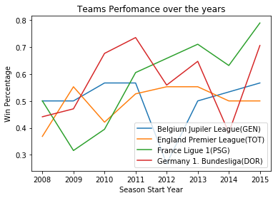

```python
""" Let's plot top 4 teams win percentage over the years (Trend) """
transposed_data['year'] = transposed_data['year'].astype(int)


plt.plot(transposed_data['year'], transposed_data.iloc[:,[1]], label=transposed_data.columns[1])
plt.plot(transposed_data['year'], transposed_data.iloc[:,[2]], label=transposed_data.columns[2])
plt.plot(transposed_data['year'], transposed_data.iloc[:,[3]], label=transposed_data.columns[3])
plt.plot(transposed_data['year'], transposed_data.iloc[:,[4]], label=transposed_data.columns[4])
plt.title('Teams Perfomance over the years')
plt.xlabel('Season Start Year')
plt.ylabel('Win Percentage')
plt.legend()
plt.show()
```

To answer the above, we can use the 'penalties' rating for all the players

```python
df_player.info()
```

```
<class 'pandas.core.frame.DataFrame'>
Int64Index: 180354 entries, 0 to 183977
Data columns (total 30 columns):
player_api_id          180354 non-null int64
player_name            180354 non-null object
rating_date            180354 non-null datetime64[ns]
penalties              180354 non-null float64
overall_rating         180354 non-null float64
attacking_work_rate    180354 non-null object
potential              180354 non-null float64
finishing              180354 non-null float64
heading_accuracy       180354 non-null float64
short_passing          180354 non-null float64
volleys                180354 non-null float64
dribbling              180354 non-null float64
curve                  180354 non-null float64
free_kick_accuracy     180354 non-null float64
long_passing           180354 non-null float64
ball_control           180354 non-null float64
acceleration           180354 non-null float64
sprint_speed           180354 non-null float64
agility                180354 non-null float64
reactions              180354 non-null float64
balance                180354 non-null float64
shot_power             180354 non-null float64
jumping                180354 non-null float64
stamina                180354 non-null float64
strength               180354 non-null float64
long_shots             180354 non-null float64
aggression             180354 non-null float64
positioning            180354 non-null float64
vision                 180354 non-null float64
marking                180354 non-null float64
dtypes: datetime64[ns](1), float64(26), int64(1), object(2)
memory usage: 42.7+ MB
```

```python
""" Fetch only the necessary columns """
df_player_interesting_cols = ['player_api_id', 'player_name', 'rating_date', 'penalties']
df_player_penalty_rating = df_player.loc[:,df_player_interesting_cols]
df_player_penalty_rating.head(5)
```

|  | player_api_id | player_name | rating_date | penalties |
| --- | --- | --- | --- | --- |
| 0 | 505942 | Aaron Appindangoye | 2016-02-18 | 48.0 |
| 1 | 505942 | Aaron Appindangoye | 2015-11-19 | 48.0 |
| 2 | 505942 | Aaron Appindangoye | 2015-09-21 | 48.0 |
| 3 | 505942 | Aaron Appindangoye | 2015-03-20 | 47.0 |
| 4 | 505942 | Aaron Appindangoye | 2007-02-22 | 47.0 |

Looking at the above data, the player has been rated multiple times in the same year, in the above table, you can see 'Aaron' was rated 2015-09-21 and 2015-03-20.

Let's calculate mean average rating per player every year.

```python
df_player_penalty_rating['rating_year'] = pd.DatetimeIndex(df_player_penalty_rating['rating_date']).year
df_player_penalty_rating.head(5)
```

|  | player_api_id | player_name | rating_date | penalties | rating_year |
| --- | --- | --- | --- | --- | --- |
| 0 | 505942 | Aaron Appindangoye | 2016-02-18 | 48.0 | 2016 |
| 1 | 505942 | Aaron Appindangoye | 2015-11-19 | 48.0 | 2015 |
| 2 | 505942 | Aaron Appindangoye | 2015-09-21 | 48.0 | 2015 |
| 3 | 505942 | Aaron Appindangoye | 2015-03-20 | 47.0 | 2015 |
| 4 | 505942 | Aaron Appindangoye | 2007-02-22 | 47.0 | 2007 |

```python
""" Calculate Player's Penalties rating average for every year """
df_avg_penalties_per_player_per_year = df_player_penalty_rating.groupby(['player_api_id','player_name',  'rating_year']).mean().reset_index()
df_avg_penalties_per_player_per_year.head(5)
```

|  | player_api_id | player_name | rating_year | penalties |
| --- | --- | --- | --- | --- |
| 0 | 2625 | Patryk Rachwal,18 | 2007 | 46.0 |
| 1 | 2625 | Patryk Rachwal,18 | 2008 | 46.0 |
| 2 | 2625 | Patryk Rachwal,18 | 2010 | 69.0 |
| 3 | 2625 | Patryk Rachwal,18 | 2011 | 66.0 |
| 4 | 2625 | Patryk Rachwal,18 | 2012 | 66.0 |

Lets find out for how many years for data we have players

```python
df_avg_penalties_per_player_per_year.groupby('rating_year').count()
```

| rating_year | player_api_id | player_name | penalties |
| --- | --- | --- | --- |
| 2007 | 10410 | 10410 | 10410 |
| 2008 | 4905 | 4905 | 4905 |
| 2009 | 5663 | 5663 | 5663 |
| 2010 | 6571 | 6571 | 6571 |
| 2011 | 7153 | 7153 | 7153 |
| 2012 | 7459 | 7459 | 7459 |
| 2013 | 7896 | 7896 | 7896 |
| 2014 | 7796 | 7796 | 7796 |
| 2015 | 7502 | 7502 | 7502 |
| 2016 | 5586 | 5586 | 5586 |

Let's make sure, we include only the players have rating from 2007 to 2016. So that, we dont include players played recently and include them for analysis (as it might skew the result)

```python
df_avg_penalties_per_player_per_year_pvt_table = df_avg_penalties_per_player_per_year.pivot_table(values='penalties', \
                                                                                  index=['player_api_id', 'player_name'], \
                                                                                  columns='rating_year').reset_index()

""" Drop the players whose rating is missing for that year """
df_avg_penalties_per_player_per_year_pvt_table = df_avg_penalties_per_player_per_year_pvt_table.dropna()
df_avg_penalties_per_player_per_year_pvt_table.columns = df_avg_penalties_per_player_per_year_pvt_table.columns.astype(str)
df_avg_penalties_per_player_per_year_pvt_table.head(5)
```

| rating_year | player_api_id | player_name | 2007 | 2008 | 2009 | 2010 | 2011 | 2012 | 2013 | 2014 | 2015 | 2016 |
| --- | --- | --- | --- | --- | --- | --- | --- | --- | --- | --- | --- | --- |
| 2 | 2768 | Jose Dorado | 63.0 | 63.0 | 63.0 | 38.0 | 13.0 | 13.0 | 37.0 | 25.00 | 16.000000 | 16.0 |
| 7 | 2805 | Ruben Perez | 63.0 | 63.0 | 60.0 | 61.0 | 56.5 | 50.0 | 50.0 | 49.75 | 49.888889 | 51.0 |
| 22 | 3517 | Alexandr Kerzhakov | 84.0 | 78.0 | 78.0 | 80.5 | 82.0 | 82.5 | 80.5 | 77.00 | 79.333333 | 80.0 |
| 23 | 3520 | Andrey Arshavin | 66.0 | 76.0 | 82.0 | 63.5 | 67.0 | 73.0 | 73.0 | 73.00 | 69.250000 | 68.0 |
| 26 | 4939 | Tim Clancy | 55.0 | 56.0 | 56.0 | 17.0 | 17.0 | 17.0 | 20.2 | 25.00 | 20.800000 | 18.0 |

```python
""" Compute average player rating for all the years """
df_avg_penalties_per_player_per_year_pvt_table['overall_avg'] = df_avg_penalties_per_player_per_year_pvt_table \
                                                                        .iloc[:,np.arange(2,12)].mean(axis=1)
```

```python
df_avg_penalties_per_player_per_year_pvt_table.sort_values(by='overall_avg', ascending=False).head(5)
```

| rating_year | player_api_id | player_name | 2007 | 2008 | 2009 | 2010 | 2011 | 2012 | 2013 | 2014 | 2015 | 2016 | overall_avg |
| --- | --- | --- | --- | --- | --- | --- | --- | --- | --- | --- | --- | --- | --- |
| 1675 | 30714 | Francesco Totti | 81.0 | 89.0 | 89.5 | 91.0 | 92.0 | 91.0 | 90.000000 | 89.818182 | 90.000000 | 88.666667 | 89.198485 |
| 1776 | 30909 | David Villa | 74.0 | 79.0 | 86.0 | 89.0 | 92.0 | 92.0 | 91.666667 | 92.000000 | 92.000000 | 92.000000 | 87.966667 |
| 1629 | 30631 | Frank Lampard | 87.0 | 88.0 | 88.0 | 88.5 | 90.0 | 91.0 | 90.333333 | 86.000000 | 84.600000 | 84.000000 | 87.743333 |
| 1174 | 26440 | Timmy Simons | 84.5 | 89.0 | 89.0 | 85.0 | 85.0 | 88.0 | 87.400000 | 87.400000 | 89.500000 | 90.000000 | 87.480000 |
| 1734 | 30843 | Robin van Persie | 80.5 | 86.0 | 86.0 | 88.0 | 91.0 | 92.0 | 89.000000 | 86.272727 | 84.666667 | 84.000000 | 86.743939 |

Now let's find the top 10 players with highest avg.

```python
top_10_players_with_penalty_rating = df_avg_penalties_per_player_per_year_pvt_table.sort_values(by='overall_avg', ascending=False) \
                                        .head(10).loc[:,['player_name', 'overall_avg']]
top_10_players_with_penalty_rating
```

| rating_year | player_name | overall_avg |
| --- | --- | --- |
| 1675 | Francesco Totti | 89.198485 |
| 1776 | David Villa | 87.966667 |
| 1629 | Frank Lampard | 87.743333 |
| 1174 | Timmy Simons | 87.480000 |
| 1734 | Robin van Persie | 86.743939 |
| 1688 | Andrea Pirlo | 86.703333 |
| 1616 | Cesc Fabregas | 86.700000 |
| 3575 | Kaka | 86.550000 |
| 1619 | Steven Gerrard | 86.488889 |
| 2175 | Samuel Eto'o | 86.230000 |

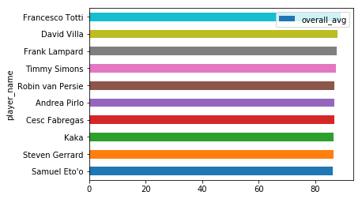

```python
top_10_players_with_penalty_rating.sort_values(by='overall_avg').plot.barh(y='overall_avg', x='player_name')
```

### Question 3: Which team attributes lead to most victories?

First lets look at the team attributes and their distributions. Lets consider year '2015' for this analysis.

```python
""" Let's get the rating year from the rating date """
df_team['rating_year'] = pd.DatetimeIndex(df_team['rating_date']).year
```

```python
""" Get the columns which has team attributes """
team_attributes_cols = [x for x in df_team.columns if '_class' in x ]
```

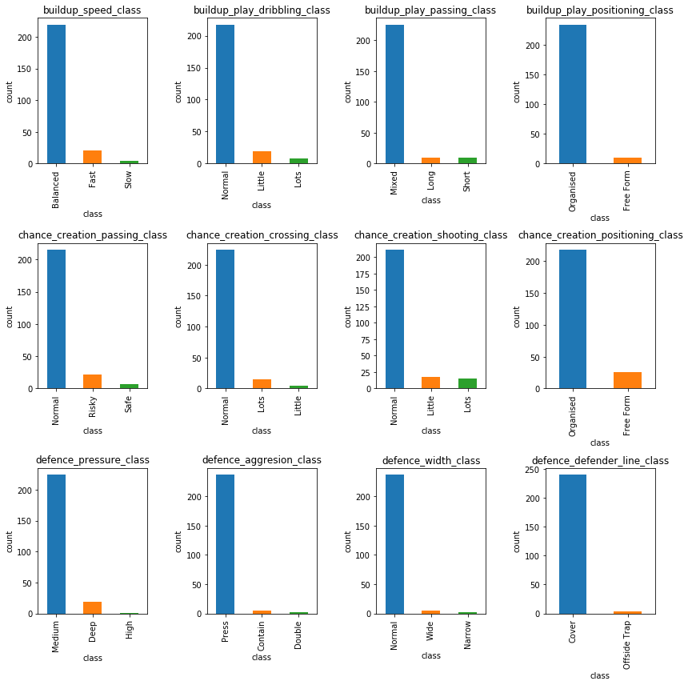

```
buildup_speed_class                   Balanced
buildup_play_dribbling_class            Little
buildup_play_passing_class               Mixed
buildup_play_positioning_class       Organised
chance_creation_passing_class           Normal
chance_creation_crossing_class          Normal
chance_creation_shooting_class          Normal
chance_creation_positioning_class    Organised
defence_pressure_class                  Medium
defence_aggresion_class                  Press
defence_width_class                     Normal
defence_defender_line_class              Cover
dtype: object
```

```python
"""This function computes popular team attributes followed most of the team """
def show_popular_team_attr(data_frame=None, rating_year=None):

    data_frame_filtered = data_frame
    """ Initial the Series """
    empty_data =  np.empty([len(team_attributes_cols)], dtype=object)
    top_team_attr_in_every_class = pd.Series(empty_data, index=team_attributes_cols)

    """Filter the data frame if rating year is provided """
    if rating_year is not None:
        data_frame_filtered = data_frame_filtered.query("rating_year == @rating_year")

    nrows = 3
    ncols = 4
    plot_index = 1
    plt.figure(figsize=(12,12))
    """ Loop through all the team attribute column and find most used team attribute for every class of team attribute """
    for c in team_attributes_cols:
        plt.subplot(nrows, ncols, plot_index)
        data_frame_filtered[team_attributes_cols[plot_index -1]].value_counts().plot(kind='bar')
        top_team_attr_in_every_class[c] = df_team[team_attributes_cols[plot_index -1]].value_counts(ascending=False).idxmax()
        plt.title(team_attributes_cols[plot_index -1])
        plt.xlabel('class')
        plt.ylabel('count')
        plot_index = plot_index + 1

    plt.tight_layout()
    plt.show()

    return top_team_attr_in_every_class

""" Get the popular team attributes for the year 2015"""
popular_team_attr_2015 = show_popular_team_attr(df_team, rating_year=2015)
popular_team_attr_2015
```

Let's find out how often the team being rated.

```python
df_team_filtered = df_team.loc[:,['team_api_id' ,'rating_year', 'buildup_speed_class']]
df_team_grouped_data = df_team_filtered.groupby(['team_api_id','rating_year']).count().reset_index()
print('{0} - No. of teams rated more than once in a year '.format( sum(df_team_grouped_data.buildup_speed_class > 1)))
print('{0} - Team rating start year'.format(df_team.rating_year.min()))
print('{0} - Team rating end year'.format(df_team.rating_year.max()))
```

```
0 - No. of teams rated more than once in a year
2010 - Team rating start year
2015 - Team rating end year
```

It seems every team is rated once in a year. So, We can assume the team attributes are rated once the season starts. Now, We can check which team attribute contributes team win or not.

Now lets find out the team matches played and win for every year (season)

```python
""" This function gets the teams' match count, won match count and attribute they have followed for a given year"""
def get_team_match_win_count_by_team_by_attr(data_frame=None, rating_year=None, team_attr_name=None):

    df_team_filtered = data_frame

    """ Filter the data frame, if rating year is provided """
    if rating_year is not None:
         df_team_filtered = data_frame.query("rating_year == @rating_year")

    """First We need to figure out the teams following different classes of attributes"""
    df_team_filtered = df_team_filtered.loc[:,['team_api_id', 'rating_year', team_attr_name]]

    """Get all the matches played by the team for that year """
    all_matches_played_by_team_by_year = get_matches_played_by_each_team(data_frame=df_match_win_matches_filtered, \
                                                                         season_start=rating_year)

    """Get all the won matches for all the team for the given year """
    won_matches_by_team_year = get_matches_won_by_teams(data_frame=df_match_win_matches_filtered, season_start=rating_year)

    """ Merge total matches and won matches for all the team """
    merged_df_matches = all_matches_played_by_team_by_year.merge(won_matches_by_team_year, how='inner' \
                                                                                  , left_on=['season_start', 'team_api_id'] \
                                                                                  , right_on=['season_start', 'winning_team'])

    """Now, merge the team attributes along with match count and won match count """
    merged_df = df_team_filtered.merge(merged_df_matches, how='inner', left_on=['team_api_id', 'rating_year'] \
                                                         ,right_on=['team_api_id', 'season_start']    )
    """Fetch only the necessary columns """
    merged_df = merged_df.loc[:,['team_api_id', 'rating_year', team_attr_name, 'total_match_count', 'win_match_count']]
    """Get the team count by team attribute they have followed """
    team_count_by_team_attr = merged_df.groupby(team_attr_name)['team_api_id'].count()
    """ Get the match count by team attribute"""
    match_count_by_team_attr = merged_df.groupby(team_attr_name)['total_match_count'].sum()

    """ Get the won match count by team attribute """
    win_count_by_team_attr = merged_df.groupby(team_attr_name)['win_match_count'].sum()

    """combine all the results for all the team attributes """
    merge_team_attr_with_match_data_df = pd.concat([team_count_by_team_attr, match_count_by_team_attr, \
                                                        win_count_by_team_attr], axis=1)
    """Compute win percentage """
    merge_team_attr_with_match_data_df['win_percentage'] = merge_team_attr_with_match_data_df['win_match_count'] / merge_team_attr_with_match_data_df['total_match_count']
    return merge_team_attr_with_match_data_df
```

```python
team_match_win_count_by_team_attr = get_team_match_win_count_by_team_by_attr(data_frame=df_team,rating_year=2015,\
                                                                             team_attr_name= 'buildup_speed_class')
team_match_win_count_by_team_attr.head(5)
```

| buildup_speed_class | team_api_id | total_match_count | win_match_count | win_percentage |
| --- | --- | --- | --- | --- |
| Balanced | 158 | 5622 | 2083 | 0.370509 |
| Fast | 15 | 534 | 247 | 0.462547 |
| Slow | 3 | 102 | 34 | 0.333333 |

From the above data, popular team attribute, may not always win the matches. For instance, 'Balanced' approach is followed by multiple teams for 'Build Up Speed', but 'Fast' approach win more matches (by looking at the win percentage).

Let's look at another team attribute 'Build Up Positioning'

```python
team_match_win_count_by_team_attr = get_team_match_win_count_by_team_by_attr(data_frame=df_team, rating_year= 2015,\
                                                                             team_attr_name= 'buildup_play_positioning_class')
team_match_win_count_by_team_attr.head(5)
```

| buildup_play_positioning_class | team_api_id | total_match_count | win_match_count | win_percentage |
| --- | --- | --- | --- | --- |
| Free Form | 10 | 348 | 176 | 0.505747 |
| Organised | 166 | 5910 | 2188 | 0.370220 |

It seems 'Free form' class is least popular among teams but it help win more matches.

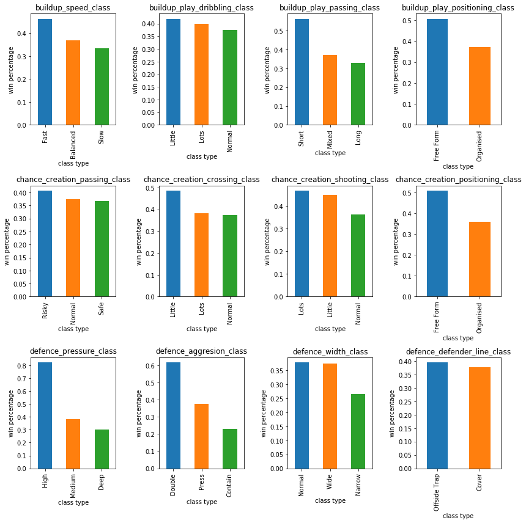

```
buildup_speed_class                          Fast
buildup_play_dribbling_class               Little
buildup_play_passing_class                  Short
buildup_play_positioning_class          Free Form
chance_creation_passing_class               Risky
chance_creation_crossing_class             Little
chance_creation_shooting_class               Lots
chance_creation_positioning_class       Free Form
defence_pressure_class                       High
defence_aggresion_class                    Double
defence_width_class                        Normal
defence_defender_line_class          Offside Trap
dtype: object
```

```python
""" This function helps to identify all the particular team attributes which help team win more matches """

def show_win_percentage_for_all_team_attr(data_frame = None, rating_year=None):


    nrows = 3
    ncols = 4
    plot_index = 1
    plt.figure(figsize=(12,12))
    empty_data =  np.empty([len(team_attributes_cols)], dtype=object)
    high_win_team_attr_in_every_class = pd.Series(empty_data, index=team_attributes_cols)
    """ Loop through all the team attributes and find the class of the team attribute which has high win percentage """
    for c in team_attributes_cols:
        plt.subplot(nrows, ncols, plot_index)
        team_match_win_count_by_team_attr = get_team_match_win_count_by_team_by_attr(data_frame=data_frame, \
                                                                                     rating_year=rating_year, \
                                                                                     team_attr_name= c)
        team_match_win_count_by_team_attr['win_percentage'].sort_values(ascending=False).plot(kind='bar')
        high_win_team_attr_in_every_class[c] = team_match_win_count_by_team_attr['win_percentage'].idxmax()
        plt.title(team_attributes_cols[plot_index -1])
        plt.xlabel('class type')
        plt.ylabel('win percentage')
        plot_index = plot_index + 1

    plt.tight_layout()
    plt.show()
    return high_win_team_attr_in_every_class

""" Let's try to get team attributes helped to win more matches for the 2015 Season """
team_attr_with_high_win_percentage_2015 = show_win_percentage_for_all_team_attr(data_frame=df_team, rating_year=2015)
team_attr_with_high_win_percentage_2015
```

The below function could be generate mark down table. It may be used for later, if needed

```python
#| This | is   |
#|------|------|
#|   a  | table|

class DictToTableConvertor(dict):
    def convert_to_table_markdown(self):
        line    =       ["| Team Attribute Class | Attribute Class Type With Highest Win %|"]
        line.append    ("|----------------------|-----------------------------------------|")
        for key, value in self.items():
            line.append("|      {0}     |     {1}            |".format(key, value))
        return line
dict_table = DictToTableConvertor(team_attr_with_high_win_percentage_2015)
lines =  dict_table.convert_to_table_markdown()
print('\n'.join(lines))
```

```
| Team Attribute Class | Attribute Class Type With Highest Win %|
|----------------------|-----------------------------------------|
|      buildup_speed_class     |     Fast            |
|      buildup_play_dribbling_class     |     Little            |
|      buildup_play_passing_class     |     Short            |
|      buildup_play_positioning_class     |     Free Form            |
|      chance_creation_passing_class     |     Risky            |
|      chance_creation_crossing_class     |     Little            |
|      chance_creation_shooting_class     |     Lots            |
|      chance_creation_positioning_class     |     Free Form            |
|      defence_pressure_class     |     High            |
|      defence_aggresion_class     |     Double            |
|      defence_width_class     |     Normal            |
|      defence_defender_line_class     |     Offside Trap            |
```

### Question 4: Is refree partial towards home team during a match?

To answer the above question, lets find out number of cards issued against the home team and away team.

```python
match_card_interesting_cols = ['home_team_api_id', 'home_team_ycard', 'home_team_rcard', 'home_team_foulcommit', \
                              'away_team_api_id', 'away_team_ycard', 'away_team_rcard', 'away_team_foulcommit' ]

df_match_card_filtered = df_match.loc[:,match_card_interesting_cols]

df_match_card_filtered['home_team_total_cards'] = df_match_card_filtered['home_team_ycard'] + \
                                                    df_match_card_filtered['home_team_rcard']
df_match_card_filtered['away_team_total_cards'] = df_match_card_filtered['away_team_ycard'] + \
                                                    df_match_card_filtered['away_team_rcard']

df_match_card_filtered['total_cards'] = df_match_card_filtered['home_team_total_cards']  + \
                                        df_match_card_filtered['away_team_total_cards']
df_match_card_filtered.head(5)
```

|  | home_team_api_id | home_team_ycard | home_team_rcard | home_team_foulcommit | away_team_api_id | away_team_ycard | away_team_rcard | away_team_foulcommit | home_team_total_cards | away_team_total_cards | total_cards |
| --- | --- | --- | --- | --- | --- | --- | --- | --- | --- | --- | --- |
| 0 | 9987 | 1.939936 | 0.10623 | 12.646899 | 9993 | 2.280905 | 0.145295 | 13.203544 | 2.046166 | 2.426199 | 4.472365 |
| 1 | 10000 | 1.939936 | 0.10623 | 12.646899 | 9994 | 2.280905 | 0.145295 | 13.203544 | 2.046166 | 2.426199 | 4.472365 |
| 2 | 9984 | 1.939936 | 0.10623 | 12.646899 | 8635 | 2.280905 | 0.145295 | 13.203544 | 2.046166 | 2.426199 | 4.472365 |
| 3 | 9991 | 1.939936 | 0.10623 | 12.646899 | 9998 | 2.280905 | 0.145295 | 13.203544 | 2.046166 | 2.426199 | 4.472365 |
| 4 | 7947 | 1.939936 | 0.10623 | 12.646899 | 9985 | 2.280905 | 0.145295 | 13.203544 | 2.046166 | 2.426199 | 4.472365 |

Let's find out the total cards in all the matches

```python
total_cards_for_all_matches = df_match_card_filtered['total_cards'].sum()
total_cards_for_all_matches
```

```
116187.5817125453
```

```python
total_cards_for_away_team_for_all_matches = df_match_card_filtered['away_team_total_cards'].sum()
total_cards_for_away_team_for_all_matches
```

```
63030.2341274309
```

```python
total_cards_for_home_team_for_all_matches = df_match_card_filtered['home_team_total_cards'].sum()
total_cards_for_home_team_for_all_matches
```

```
53157.347585114396
```

```python
away_team_card_percentage = total_cards_for_away_team_for_all_matches /total_cards_for_all_matches
home_team_card_percentage = total_cards_for_home_team_for_all_matches /total_cards_for_all_matches
```

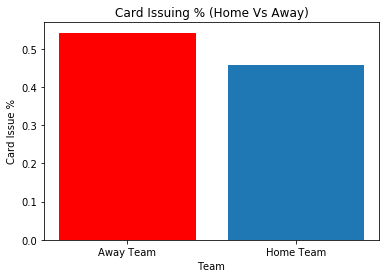

```python
barlist = plt.bar(['Away Team', 'Home Team'] ,[away_team_card_percentage,home_team_card_percentage ])
barlist[0].set_color('r')
plt.ylabel('Card Issue %')
plt.xlabel('Team')
plt.title('Card Issuing % (Home Vs Away)')
plt.show()
```

It seems Away team is getting more cards than Home Team. Let's see who commits more fouls and check its related.

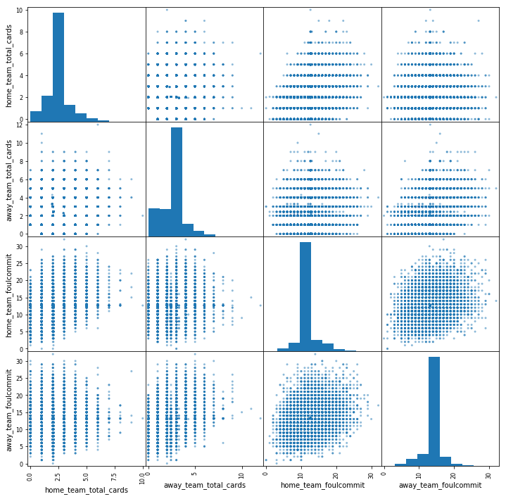

```python
match_card_and_foul_interesting_cols = ['home_team_total_cards', 'away_team_total_cards', 'home_team_foulcommit', 'away_team_foulcommit']
df_match_card_and_foul = df_match_card_filtered.loc[:,match_card_and_foul_interesting_cols]
pd.plotting.scatter_matrix(df_match_card_and_foul, figsize=(12,12));
```

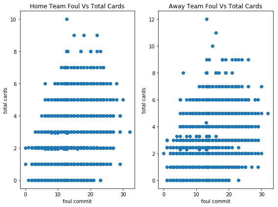

```python
""" This function gets the correlation between foul committed by team and cards issued to the team
for both away and home team team """
def show_correlation_between_home_and_away_teams_cards(data_frame=None):
    plt.figure(figsize=(8,6))

    plt.subplot(1, 2, 1)
    plt.scatter(x=data_frame['home_team_foulcommit'], y = data_frame['home_team_total_cards'])
    plt.title('Home Team Foul Vs Total Cards')
    plt.xlabel('foul commit')
    plt.ylabel('total cards')
    plt.subplot(1, 2, 2)
    plt.scatter(x=data_frame['away_team_foulcommit'], y = data_frame['away_team_total_cards'])
    plt.title('Away Team Foul Vs Total Cards')
    plt.xlabel('foul commit')
    plt.ylabel('total cards')
    plt.tight_layout()
    plt.show()
    return None

show_correlation_between_home_and_away_teams_cards(df_match_card_and_foul)
```

From the above plots, it seems foul commit is positively correlated to cards issued. Though the away teams tends to get more cards than home team, it seems away team commits more fouls. So the refree is fare.

### Question 5: What are the chances of away team winning a game, even after committing more fouls than home team?

For this, we need to find two things:

1. Determine whether its home win or away win
2. Away Win counts, when away team commits more fouls than home team

```python
match_foulcommit_interesting_cols = ['home_team_api_id', 'home_team_goals', 'home_team_foulcommit', \
                                     'away_team_api_id', 'away_team_goals', 'away_team_foulcommit' ]

""" Filter the data frame with only interested columns"""
df_match_foulcommit_filtered = df_match.loc[:,match_foulcommit_interesting_cols]


"""Ignore any drawn matches"""
df_match_foulcommit_filtered = df_match_foulcommit_filtered[~(df_match_foulcommit_filtered['home_team_goals'] == df_match_foulcommit_filtered['away_team_goals'])]
df_match_foulcommit_filtered.head(5)
```

|  | home_team_api_id | home_team_goals | home_team_foulcommit | away_team_api_id | away_team_goals | away_team_foulcommit |
| --- | --- | --- | --- | --- | --- | --- |
| 2 | 9984 | 0 | 12.646899 | 8635 | 3 | 13.203544 |
| 3 | 9991 | 5 | 12.646899 | 9998 | 0 | 13.203544 |
| 4 | 7947 | 1 | 12.646899 | 9985 | 3 | 13.203544 |
| 7 | 4049 | 1 | 12.646899 | 9996 | 2 | 13.203544 |
| 8 | 10001 | 1 | 12.646899 | 9986 | 0 | 13.203544 |

```python
"""Determine whether its Home Win or Away Win """

df_match_foulcommit_filtered['match_result'] = np.where( \
                df_match_foulcommit_filtered['home_team_goals'] > df_match_foulcommit_filtered['away_team_goals'] , \
                'HomeWin', \
                'AwayWin')
df_match_foulcommit_filtered.head(5)
```

|  | home_team_api_id | home_team_goals | home_team_foulcommit | away_team_api_id | away_team_goals | away_team_foulcommit | match_result |
| --- | --- | --- | --- | --- | --- | --- | --- |
| 2 | 9984 | 0 | 12.646899 | 8635 | 3 | 13.203544 | AwayWin |
| 3 | 9991 | 5 | 12.646899 | 9998 | 0 | 13.203544 | HomeWin |
| 4 | 7947 | 1 | 12.646899 | 9985 | 3 | 13.203544 | AwayWin |
| 7 | 4049 | 1 | 12.646899 | 9996 | 2 | 13.203544 | AwayWin |
| 8 | 10001 | 1 | 12.646899 | 9986 | 0 | 13.203544 | HomeWin |

```
Total Matches with Results: 19383

Match Results (Away Win Vs Home Win)
match_result
AwayWin     7466
HomeWin    11917
Name: home_team_api_id, dtype: int64
Percentage of AwayWin: 0.38518289222514573
Percentage of HomeWin: 0.6148171077748542
```

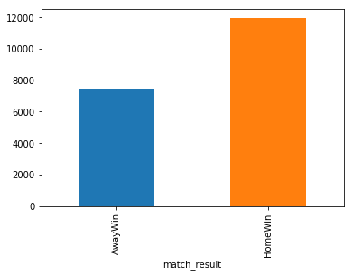

```python
match_count_with_result = df_match_foulcommit_filtered.shape[0]
team_win_count = df_match_foulcommit_filtered.groupby('match_result')['home_team_api_id'].count()

print('Total Matches with Results: {0}\n'.format(df_match_foulcommit_filtered.shape[0]))
print('Match Results (Away Win Vs Home Win)')
print(team_win_count)
print('Percentage of AwayWin: {0}'.format(team_win_count['AwayWin']/match_count_with_result))
print('Percentage of HomeWin: {0}'.format(team_win_count['HomeWin']/match_count_with_result))
team_win_count.plot(kind='bar');
```

From the above graph, it seems Home Team tends to win more than Away Team

Out of 19383 (match with result), 'Away Team' won only 7466 matches. Chance of 'Away Team' winning a match is 0.38.

Now, lets particularly look at the Away team win matches and see if away team's chances of winning a match

```python
df_match_foulcommit_filtered_away_win = df_match_foulcommit_filtered[df_match_foulcommit_filtered['match_result'] == 'AwayWin']
matches_away_team_committed_more_fouls = df_match_foulcommit_filtered_away_win[df_match_foulcommit_filtered_away_win['away_team_foulcommit'] > df_match_foulcommit_filtered_away_win['home_team_foulcommit'] ]
away_team_win_count_committing_more_fouls = matches_away_team_committed_more_fouls['match_result'].value_counts()
away_team_win_count_committing_more_fouls
```

```
AwayWin    6136
Name: match_result, dtype: int64
```

```python
print('Percentage of Away Win even after committing more fouls than home team: {0}'.format( \
      away_team_win_count_committing_more_fouls['AwayWin']/match_count_with_result))
```

```
Percentage of Away Win even after committing more fouls than home team: 0.3165660630449363
```

Away team chances of winning reduces only by a few margin from '0.38' to '0.32' (rounding 0.3165660630449363), when they commit more fouls.

## Conclusion

### Question 1 Which Soccer team have improved the most over the period of time?

From the year 2008 to 2015, Below is the list of teams from each league who has improved over the period. Of all the teams, 'Napoli (NAP)' win percentage improved from 31.58% to 65.79%.

```python
team_improved_the_most_from_each_league.loc[:,[2008, 2015, 'team_league_name', 'overall_win_percentage_change']].sort_values(by='overall_win_percentage_change', ascending=False)
```

|  | 2008 | 2015 | team_league_name | overall_win_percentage_change |
| --- | --- | --- | --- | --- |
| 4 | 0.315789 | 0.657895 | Italy Serie A(NAP) | 0.342105 |
| 2 | 0.500000 | 0.789474 | France Ligue 1(PSG) | 0.289474 |
| 7 | 0.566667 | 0.852941 | Portugal Liga ZON Sagres(BEN) | 0.286275 |
| 3 | 0.441176 | 0.705882 | Germany 1. Bundesliga(DOR) | 0.264706 |
| 8 | 0.368421 | 0.578947 | Scotland Premier League(ABE) | 0.210526 |
| 9 | 0.526316 | 0.736842 | Spain LIGA BBVA(AMA) | 0.210526 |
| 5 | 0.205882 | 0.411765 | Netherlands Eredivisie(HER) | 0.205882 |
| 10 | 0.250000 | 0.416667 | Switzerland Super League(LUZ) | 0.166667 |
| 1 | 0.368421 | 0.500000 | England Premier League(TOT) | 0.131579 |
| 0 | 0.500000 | 0.566667 | Belgium Jupiler League(GEN) | 0.066667 |
| 6 | 0.300000 | 0.366667 | Poland Ekstraklasa(CHO) | 0.066667 |

### Question 2: Which Soccer Player has the best rating for penalties?

Below is the list of players with highest penalty average

```python
top_10_players_with_penalty_rating
```

| rating_year | player_name | overall_avg |
| --- | --- | --- |
| 1675 | Francesco Totti | 89.198485 |
| 1776 | David Villa | 87.966667 |
| 1629 | Frank Lampard | 87.743333 |
| 1174 | Timmy Simons | 87.480000 |
| 1734 | Robin van Persie | 86.743939 |
| 1688 | Andrea Pirlo | 86.703333 |
| 1616 | Cesc Fabregas | 86.700000 |
| 3575 | Kaka | 86.550000 |
| 1619 | Steven Gerrard | 86.488889 |
| 2175 | Samuel Eto'o | 86.230000 |

It seems 'Francesco Totti' tops the penalty rating. We can also look at the penalty rating for him over the years

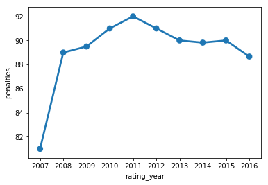

```python
totti_penalty_rating = df_player[df_player['player_name'] == 'Francesco Totti'].loc[:, ['rating_date','penalties']]
totti_penalty_rating['rating_year'] = pd.DatetimeIndex(totti_penalty_rating['rating_date']).year
totti_penalty_rating_avg_year = totti_penalty_rating.groupby('rating_year')['penalties'].mean().reset_index()
totti_penalty_rating_avg_year
sns.pointplot(x='rating_year', y='penalties', data=totti_penalty_rating_avg_year)
```

We can conclude has always been rated high throught his careers, except the dip during his initial career stage

### Question 3: Which team attributes lead to most victories?

Here is the list of popular attribute type followed by differnt teams for the year 2015

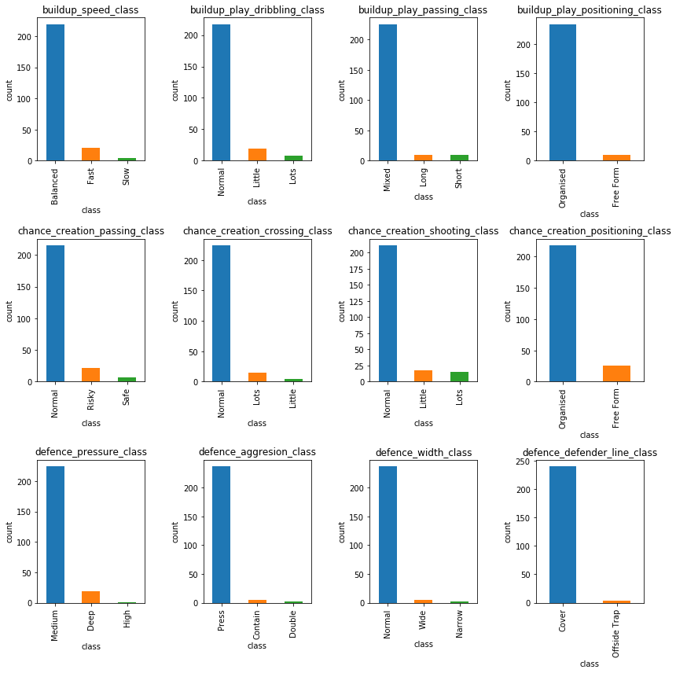

```python
popular_team_attr_2015 = show_popular_team_attr(data_frame= df_team, rating_year=2015)
```

Here is the list of team attributes which provided maximum victories (proposition-wise)

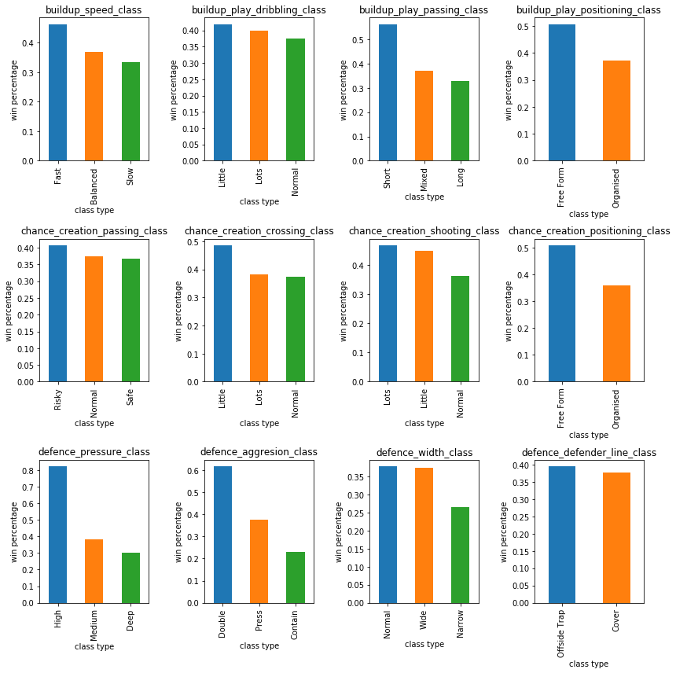

```python
high_win_percentage_team_attr_2015 = show_win_percentage_for_all_team_attr(data_frame= df_team, rating_year=2015)
```

```python
df_team_attr_popular_versus_high_win = pd.concat([popular_team_attr_2015, high_win_percentage_team_attr_2015], axis=1)
df_team_attr_popular_versus_high_win.columns = ['popular_attribute_type', 'high_win_attribute_type']
df_team_attr_popular_versus_high_win
```

|  | popular_attribute_type | high_win_attribute_type |
| --- | --- | --- |
| buildup_speed_class | Balanced | Fast |
| buildup_play_dribbling_class | Little | Little |
| buildup_play_passing_class | Mixed | Short |
| buildup_play_positioning_class | Organised | Free Form |
| chance_creation_passing_class | Normal | Risky |
| chance_creation_crossing_class | Normal | Little |
| chance_creation_shooting_class | Normal | Lots |
| chance_creation_positioning_class | Organised | Free Form |
| defence_pressure_class | Medium | High |
| defence_aggresion_class | Press | Double |
| defence_width_class | Normal | Normal |
| defence_defender_line_class | Cover | Offside Trap |

From the above table, We can conclude that popular team attribute may not always win the matches.

### Question 4 Is refree partial towards home team during a match?

Though 'Away Team' tends to get more cards than 'Home Team' (as explained in Exploratory Data Analysis Phase). It seems the 'Away Team' commits more foul than 'Home Team', as we can see the positive correlation between cards and foul commits.

So, Refree is fare. Its the away team who tends to commit more fouls responsible for getting more cards against them.

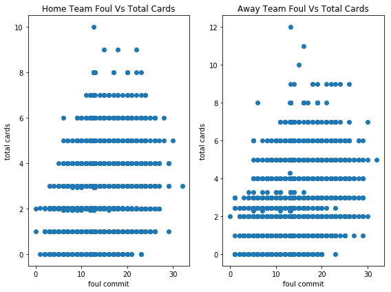

```python
show_correlation_between_home_and_away_teams_cards(df_match_card_and_foul)
```

### Question 5 What are the chances of away team winning a game, even after committing more fouls than home team?

'Away Team' foul commits has minimal effect on 'Away Team' winning a match.

```python
print('Total Matches with Results: {0}\n'.format(df_match_foulcommit_filtered.shape[0]))
print('Match Results (Away Win Vs Home Win)')
print(team_win_count)
print('Percentage of AwayWin: {0}'.format(team_win_count['AwayWin']*100/match_count_with_result))
print('Percentage of HomeWin: {0}'.format(team_win_count['HomeWin']*100/match_count_with_result))
print('Percentage of Away Win even after committing more fouls than home team: {0}'.format( \
      away_team_win_count_committing_more_fouls['AwayWin']*100/match_count_with_result))
```

```
Total Matches with Results: 19383

Match Results (Away Win Vs Home Win)
match_result
AwayWin     7466
HomeWin    11917
Name: home_team_api_id, dtype: int64
Percentage of AwayWin: 38.518289222514575
Percentage of HomeWin: 61.481710777485425
Percentage of Away Win even after committing more fouls than home team: 31.65660630449363
```